# Biostat 212a Homework 2

Due Feb 6, 2024 @ 11:59PM

Author

Jiyin (Jenny) Zhang, UID:606331859

Published

February 6, 2024

## 1 ISL Exercise 4.8.1 (10pts)

1. Using a little bit of algebra, prove that $p(X)=\frac{e^{\beta_0+\beta_1X}}{1+e^{\beta_0+\beta_1X}}$ is equivalent to $\frac {p(X)} {1-p(X)} = e^{\beta_0+\beta_1X}$. In other words, the logistic function representation and logit representation for the logistic regression model are equivalent.

**Answer:**

$$\begin{aligned}
P(x)(1+^{\beta_0 + \beta_1x}) &= e^{\beta_0 + \beta_1x} \Rightarrow \\
(1+^{\beta_0 + \beta_1x} &= \frac {1} {\frac{1}{1 + e^{\beta_0 + \beta_1x}}}) \\
\frac{P(x)}{\frac{1}{1 + e^{\beta_0 + \beta_1x}}} &= e^{\beta_0 + \beta_1x} \Rightarrow\\
\frac{P(x)}{1 - \frac{e^{\beta_0 + \beta_1x}}{1+ e^{\beta_0 + \beta_1x}}} &= e^{\beta_0 + \beta_1x} \Rightarrow\\
\frac{P(x)}{1 - P(x)} &= e^{\beta_0 + \beta_1x} \\
\end{aligned}$$
Therefore, the logistic function representation and logit representation for the logistic regression model are equivalent.

## 2 ISL Exercise 4.8.6 (10pts)

Suppose we collect data for a group of students in a statistics class with variables $X_1$ = hours studied, $X_2$ = undergrad GPA, and $Y$ = receive an A. We fit a logistic regression and produce estimated coefficient, $\hat {\beta _0}$ = −6, $\hat {\beta _1}$ = 0.05, $\hat {\beta _2}$  
= 1. **(a)** Estimate the probability that a student who studies for 40 h and has an undergrad GPA of 3.5 gets an A in the class.

**Answer:** The probability that a student who studies for 40 hours and has an undergrad GPA of 3.5 gets an A in the class is 0.3775407.

$$\begin{aligned}
p(X) &= \frac{\exp(\hat\beta_0 + \hat\beta_1X_1 +
\hat\beta_2X_2)}{1 + \exp(\hat\beta_0 + \hat\beta_1X_1 + \hat\beta_2X_2)}\\
&= \frac{\exp(-6 + 0.05*40 + 1*3.5)}{1+\exp(-6 + 0.05*40 + 1*3.5)} \\
&= \frac{\exp(-0.5)}{1+\exp(-0.5)} \\
&= 0.3775407
\end{aligned}$$

**(b)** How many hours would the student in part (a) need to study to have a 50 % chance of getting an A in the class?

**Answer:** The student in part (a) would need to study for 50 hours to have a 50% chance of getting an A in the class.

$$\begin{aligned}
\log(\frac{p(X)}{1 - p(X)}) = \hat\beta_0 + \hat\beta_0*X_1 + \hat\beta_2*X_2\\
Assign \ the \ values \ of \ p(X), \ X_1, \ X_2, \ \hat\beta_0, \ \hat\beta_0, \ \hat\beta_2 \ to \ the \ equation,\\
\log(\frac{0.5}{1 - 0.5}) = -6 + 0.05*X_1 + 1*3.5\\
Solve \ the \ equation: \ X_1 = 50 \ hours.
\end{aligned}$$

## 3 ISL Exercise 4.8.9 (10pts)

This problem has to do with odds.

**(a)** On average, what fraction of people with an odds of 0.37 of defaulting on their credit card payment will in fact default?

**Answer:** On average, 0.270073 of people with an odds of 0.37 of defaulting on their credit card payment will in fact default.

$$\begin{aligned}
odds &= \frac{p(X)}{1-p(X)}\\
p(X) &= odds*(1-p(X)) = odds-odds*p(X) \\
odds &= p(X) + odds*p(X) = (1 + odds) * p(X) \\
p(X) &= \frac{odds}{1 + odds} \\
&= \frac{0.37}{1+0.37} = 0.270073
\end{aligned}$$

**(b)** Suppose that an individual has a 16 % chance of defaulting on credit card payment. What are the odds that she will default?

**Answer:** The odds that she will default is 0.1904762.

$$\begin{aligned}
odds &= \frac{p(X)}{1-p(X)}\\
odds &= \frac{0.16}{1-0.16}=0.1904762
\end{aligned}$$
## ISL Exercise 4.8.13 (a)-(i) (50pts)

This question should be answered using the **Weekly** data set, which is part of the **ISLR2** package. This data is similar in nature to the **Smarket** data from this chapter’s lab, except that it contains 1, 089 weekly returns for 21 years, from the beginning of 1990 to the end of 2010.

**(a)** Produce some numerical and graphical summaries of the **Weekly** data. Do there appear to be any patterns?

**Answer:**

```r
# Load the ISLR2 package and the Weekly dataset
# install.packages("ISLR2")
library(ISLR2)
data(Weekly)
```

```r
# Display the structure and summary of the dataset -- numerical summaries
summary(Weekly)
```

```
      Year           Lag1               Lag2               Lag3
 Min.   :1990   Min.   :-18.1950   Min.   :-18.1950   Min.   :-18.1950
 1st Qu.:1995   1st Qu.: -1.1540   1st Qu.: -1.1540   1st Qu.: -1.1580
 Median :2000   Median :  0.2410   Median :  0.2410   Median :  0.2410
 Mean   :2000   Mean   :  0.1506   Mean   :  0.1511   Mean   :  0.1472
 3rd Qu.:2005   3rd Qu.:  1.4050   3rd Qu.:  1.4090   3rd Qu.:  1.4090
 Max.   :2010   Max.   : 12.0260   Max.   : 12.0260   Max.   : 12.0260
      Lag4               Lag5              Volume            Today
 Min.   :-18.1950   Min.   :-18.1950   Min.   :0.08747   Min.   :-18.1950
 1st Qu.: -1.1580   1st Qu.: -1.1660   1st Qu.:0.33202   1st Qu.: -1.1540
 Median :  0.2380   Median :  0.2340   Median :1.00268   Median :  0.2410
 Mean   :  0.1458   Mean   :  0.1399   Mean   :1.57462   Mean   :  0.1499
 3rd Qu.:  1.4090   3rd Qu.:  1.4050   3rd Qu.:2.05373   3rd Qu.:  1.4050
 Max.   : 12.0260   Max.   : 12.0260   Max.   :9.32821   Max.   : 12.0260
 Direction
 Down:484
 Up  :605
```

Looking at the summary statistics for the Weekly dataset, we can observe the following patterns:

**Return Trends:**

The median and mean values for these lagged variables are close to zero and almost identical, indicating that there is no significant overall upward or downward trend in the percentage return.

**Volume of Trading:**

The trading volume (Volume) has a wide range, with the median being around 1.0. This suggests that the volume of trading varies widely across different weeks.

**Daily Returns:**

The median value for the variable “Today” is positive, indicating that, on average, the stock market tends to have a positive return on a weekly basis.

**Direction:**

The dataset contains more instances of “Up” (605 observations) than “Down” (484 observations), suggesting a slight imbalance in the classes.

```r
# Correlation matrix
cor(Weekly[, c("Year", "Lag1", "Lag2", "Lag3", "Lag4", "Lag5", "Volume")])
```

```
              Year         Lag1        Lag2        Lag3        Lag4
Year    1.00000000 -0.032289274 -0.03339001 -0.03000649 -0.03112792
Lag1   -0.03228927  1.000000000 -0.07485305  0.05863568 -0.07127388
Lag2   -0.03339001 -0.074853051  1.00000000 -0.07572091  0.05838153
Lag3   -0.03000649  0.058635682 -0.07572091  1.00000000 -0.07539587
Lag4   -0.03112792 -0.071273876  0.05838153 -0.07539587  1.00000000
Lag5   -0.03051910 -0.008183096 -0.07249948  0.06065717 -0.07567503
Volume  0.84194162 -0.064951313 -0.08551314 -0.06928771 -0.06107462
               Lag5      Volume
Year   -0.030519101  0.84194162
Lag1   -0.008183096 -0.06495131
Lag2   -0.072499482 -0.08551314
Lag3    0.060657175 -0.06928771
Lag4   -0.075675027 -0.06107462
Lag5    1.000000000 -0.05851741
Volume -0.058517414  1.00000000
```

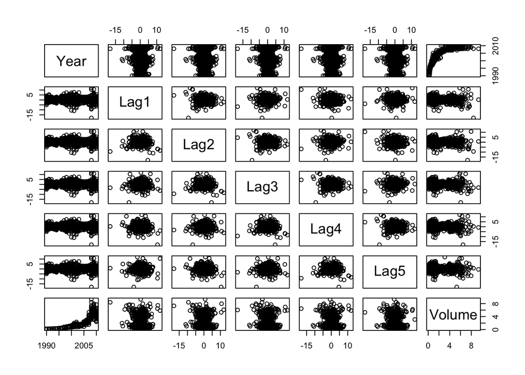

```r
# Create a scatter plot matrix for numerical variables
pairs(Weekly[, c("Year", "Lag1", "Lag2", "Lag3", "Lag4", "Lag5", "Volume")])
```

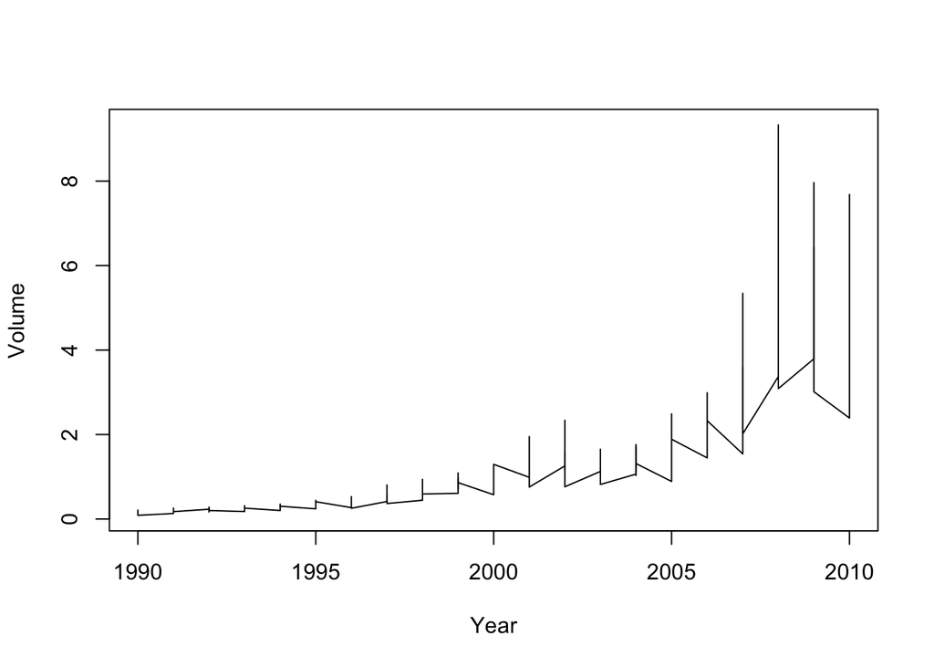

```r
# Create a time series plot of the Weekly data
plot(Weekly$Year, Weekly$Volume, type = "l", xlab = "Year", ylab = "Volume")
```

There is a strong positive correlation (0.84) between the “Year” and “Volume” variables. This suggests that the trading volume tends to increase over the years. The line plot of the trading volume over the years also shows an increasing trend.

The scatter plot matrix shows that there is no strong linear relationship between the lagged returns (Lag1 to Lag5) and the trading volume. The correlation matrix also confirms this observation, with correlation coefficients close to zero for these variables.

**(b)** Use the full data set to perform a logistic regression with **Direction** as the response and the five lag variables plus **Volume** as predictors. Use the summary function to print the results. Do any of the predictors appear to be statistically significant? If so, which ones?

**Answer:**

```r
# Fit logistic regression model
model <- glm(
  Direction ~ Lag1 + Lag2 + Lag3 + Lag4 + Lag5 + Volume,
  data = Weekly,
  family = "binomial"
  )

# Print the summary of the model
summary(model)
```

```
Call:
glm(formula = Direction ~ Lag1 + Lag2 + Lag3 + Lag4 + Lag5 +
    Volume, family = "binomial", data = Weekly)

Coefficients:
            Estimate Std. Error z value Pr(>|z|)
(Intercept)  0.26686    0.08593   3.106   0.0019 **
Lag1        -0.04127    0.02641  -1.563   0.1181
Lag2         0.05844    0.02686   2.175   0.0296 *
Lag3        -0.01606    0.02666  -0.602   0.5469
Lag4        -0.02779    0.02646  -1.050   0.2937
Lag5        -0.01447    0.02638  -0.549   0.5833
Volume      -0.02274    0.03690  -0.616   0.5377
---
Signif. codes:  0 '***' 0.001 '**' 0.01 '*' 0.05 '.' 0.1 ' ' 1

(Dispersion parameter for binomial family taken to be 1)

    Null deviance: 1496.2  on 1088  degrees of freedom
Residual deviance: 1486.4  on 1082  degrees of freedom
AIC: 1500.4

Number of Fisher Scoring iterations: 4
```

Lag2 appears to be statistically significant. The p-value for Lag2 is less than 0.05.

**(c)** Compute the confusion matrix and overall fraction of correct predictions. Explain what the confusion matrix is telling you about the types of mistakes made by logistic regression.

**Answer:**

```r
# Make predictions
predictions <- predict(model, type = "response")

# Convert probabilities to predicted classes (Up or Down)
predicted_classes <- ifelse(predictions > 0.5, "Up", "Down")

# Create a confusion matrix
conf_matrix <- table(
  Actual = Weekly$Direction,
  Predicted = predicted_classes
  )

# Print the confusion matrix
print(conf_matrix)
```

```
      Predicted
Actual Down  Up
  Down   54 430
  Up     48 557
```

```r
# Compute overall fraction of correct predictions
accuracy <- sum(diag(conf_matrix)) / sum(conf_matrix)
cat("Overall Accuracy: (54 + 557) / (54 + 557 + 48 + 430) = ", accuracy, "\n")
```

```
Overall Accuracy: (54 + 557) / (54 + 557 + 48 + 430) =  0.5610652
```

Above is the confusion matrix for the logistic regression model. The overall fraction of correct predictions is 0.5610652.

**False Positives (Type I Error):**

Instances where the actual direction was “Down” (row 1), but the model predicted “Up” (column 2). There are 430 occurrences of this. In the context of stock market prediction, this means the model falsely predicted an “Up” movement when the actual movement was “Down.”

**False Negatives (Type II Error):**

Instances where the actual direction was “Up” (row 2), but the model predicted “Down” (column 1). There are 48 occurrences of this. In the context of stock market prediction, this means the model falsely predicted a “Down” movement when the actual movement was “Up.”

**(d)** Now fit the logistic regression model using a training data period from 1990 to 2008, with **Lag2** as the only predictor. Compute the confusion matrix and the overall fraction of correct predictions for the held out data (that is, the data from 2009 and 2010).

**Answer:**

Split the data into training (1990-2008) and testing (2009-2010) sets:

```r
train_data <- subset(Weekly, Year >= 1990 & Year <= 2008)
test_data <- subset(Weekly, Year >= 2009)
```

Fit logistic regression with Lag2 as the predictor:

```r
model <- glm(Direction ~ Lag2, data = train_data, family = "binomial")
```

Make predictions on the test set:

```r
predictions <- predict(model, newdata = test_data, type = "response")
```

Confusion matrix:

```r
# Convert probabilities to class predictions (Up or Down)
predicted_direction <- ifelse(predictions > 0.5, "Up", "Down")

# Create a confusion matrix
conf_matrix <- table(Actual = test_data$Direction, Predicted = predicted_direction)

# Print confusion matrix
print(conf_matrix)
```

```
      Predicted
Actual Down Up
  Down    9 34
  Up      5 56
```

```r
# Calculate overall fraction of correct predictions
accuracy <- sum(diag(conf_matrix)) / sum(conf_matrix)
cat("Overall Accuracy:", accuracy, "\n")
```

```
Overall Accuracy: 0.625
```

Above is the confusion matrix and the overall fraction of correct predictions for the held out data is 0.625.

**(e)** Repeat (d) using LDA.

**Answer:**

```r
# Install and load the MASS package if not already installed
# install.packages("MASS")
library(MASS)
```

```r
# Fit LDA model
lda_model <- lda(Direction ~ Lag2, data = train_data)
```

```r
# Make predictions on the test set
predictions <- predict(lda_model, newdata = test_data)
```

```r
# Convert predictions to class labels
predicted_direction <- predictions$class

# Create a confusion matrix
conf_matrix <- table(Actual = test_data$Direction, Predicted = predicted_direction)

# Print confusion matrix
print(conf_matrix)
```

```
      Predicted
Actual Down Up
  Down    9 34
  Up      5 56
```

```r
# Calculate overall fraction of correct predictions
accuracy <- sum(diag(conf_matrix)) / sum(conf_matrix)
cat("Overall Accuracy:", accuracy, "\n")
```

```
Overall Accuracy: 0.625
```

Above is the confusion matrix and the overall fraction of correct predictions for the held out data is 0.625.

**(f)** Repeat (d) using QDA.

**Answer:**

```r
# Fit QDA model
qda_model <- qda(Direction ~ Lag2, data = train_data)
```

```r
# Make predictions on the test set
predictions <- predict(qda_model, newdata = test_data)
```

```r
# Convert predictions to class labels
predicted_direction <- predictions$class

# Create a confusion matrix
conf_matrix <- table(
  Actual = test_data$Direction,
  Predicted = predicted_direction
  )

# Print confusion matrix
print(conf_matrix)
```

```
      Predicted
Actual Down Up
  Down    0 43
  Up      0 61
```

```r
# Calculate overall fraction of correct predictions
accuracy <- sum(diag(conf_matrix)) / sum(conf_matrix)
cat("Overall Accuracy:", accuracy, "\n")
```

```
Overall Accuracy: 0.5865385
```

Above is the confusion matrix and the overall fraction of correct predictions for the held out data is 0.5865385.

**(g)** Repeat (d) using KNN with K = 1.

**Answer:**

```r
# install.packages("class")
library(class)
```

```r
# Fit KNN model with k=1
knn_model <- knn(
  train = as.matrix(train_data$Lag2),
  test = as.matrix(test_data$Lag2),
  cl = train_data$Direction,
  k = 1
  )

# Create a confusion matrix
conf_matrix <- table(Actual = test_data$Direction, Predicted = knn_model)

# Print confusion matrix
print(conf_matrix)
```

```
      Predicted
Actual Down Up
  Down   21 22
  Up     30 31
```

```r
# Calculate overall fraction of correct predictions
accuracy <- sum(diag(conf_matrix)) / sum(conf_matrix)
cat("Overall Accuracy:", accuracy, "\n")
```

```
Overall Accuracy: 0.5
```

**(h)** Repeat (d) using naive Bayes.

**Answer:**

```r
# install.packages("naivebayes")
library(naivebayes)
```

```r
# Fit Naive Bayes model
nb_model <- naive_bayes(Direction ~ Lag2, data = train_data)

# Make predictions on the test set
nb_predictions <- predict(nb_model, newdata = test_data, type = "class")
# Create a confusion matrix
conf_matrix <- table(Actual = test_data$Direction, Predicted = nb_predictions)

# Print confusion matrix
print(conf_matrix)
```

```
      Predicted
Actual Down Up
  Down    0 43
  Up      0 61
```

```r
# Calculate overall fraction of correct predictions
accuracy <- sum(diag(conf_matrix)) / sum(conf_matrix)
cat("Overall Accuracy:", accuracy, "\n")
```

```
Overall Accuracy: 0.5865385
```

Above is the confusion matrix and the overall fraction of correct predictions for the held out data is 0.5865385.

**(i)** Which of these methods appears to provide the best results on this data?

**Answer:**

Logistic regression and LDA appear to provide the best results on this data. These two methods give the exact same confusion matrix. The overall accuracy for both methods is 0.625, which is highest among other methods.

## 4 Bonus question: ISL Exercise 4.8.13 Part (j) (30pts)

Experiment with different combinations of predictors, including possible transformations and interactions, for each of the methods. Report the variables, method, and associated confusion matrix that appears to provide the best results on the held out data. Note that you should also experiment with values for K in the KNN classifier.

**Answer:**

Below experiment with different combinations of predictors. Since lag2 is the only statistically significant predictor, now first I will use combination of lag1 and lag2, lag3 and lag2, lag4 and lag2, lag5 and lag2, volume and lag2 to see if there are interactions between them.

And keeping lag2 always as one of the predictors, adding 2 more variables to see if there are interactions between them.

Then, I will add 3 more variables.

Finally, I will add 4 more variables.

**(1)** Logistic Regression model:

**2 predictors**

```r
for (lag in c("Lag1", "Lag3", "Lag4", "Lag5", "Volume")) {
  formula_str <- paste("Direction ~ Lag2 +", lag)
  formula_obj <- as.formula(formula_str)
  # Fit logistic regression with Lag2 and another lag as the predictors
  model <- glm(formula_obj, data = train_data, family = "binomial")
  # Make predictions on the test set
  predictions <- predict(model, newdata = test_data, type = "response")
  # Convert probabilities to class predictions (Up or Down)
  predicted_direction <- ifelse(predictions > 0.5, "Up", "Down")
  # Create a confusion matrix
  conf_matrix <- table(Actual = test_data$Direction, Predicted = predicted_direction)
  # Print confusion matrix
  print(conf_matrix)
  # Calculate overall fraction of correct predictions
  accuracy <- sum(diag(conf_matrix)) / sum(conf_matrix)
  cat("Interaction of Lag2 and",lag,"'s Overall Accuracy:", accuracy, "\n")
}
```

```
      Predicted
Actual Down Up
  Down    7 36
  Up      8 53
Interaction of Lag2 and Lag1 's Overall Accuracy: 0.5769231
      Predicted
Actual Down Up
  Down    8 35
  Up      4 57
Interaction of Lag2 and Lag3 's Overall Accuracy: 0.625
      Predicted
Actual Down Up
  Down    8 35
  Up      4 57
Interaction of Lag2 and Lag4 's Overall Accuracy: 0.625
      Predicted
Actual Down Up
  Down    7 36
  Up      5 56
Interaction of Lag2 and Lag5 's Overall Accuracy: 0.6057692
      Predicted
Actual Down Up
  Down   20 23
  Up     25 36
Interaction of Lag2 and Volume 's Overall Accuracy: 0.5384615
```

Compared with the overall fraction of correct predictions with Lag2 only (0.625), the interaction of Lag2 and Lag3’s overall accuracy is 0.625 and the interaction of Lag2 and Lag4’s overall accuracy is 0.625. Therefore, there is no interaction between Lag2 and Lag3, and Lag2 and Lag4. While the interaction of Lag2 and Lag1’s overall accuracy is 0.5769231. The interaction of Lag2 and Lag5’s overall accuracy is 0.6057692. The interaction of Lag2 and Volume’s overall accuracy is 0.5384615. Therefore, there is negative interaction between Lag2 and Lag1, Lag2 and Lag5, and Lag2 and Volume.

**3 predictors**

Lag2, Lag1 and Lag3:

```r
# Fit logistic regression with Lag2 and another lag as the predictors
model <- glm(Direction ~ Lag2 + Lag1 + Lag3, data = train_data, family = "binomial")
# Make predictions on the test set
predictions <- predict(model, newdata = test_data, type = "response")
# Convert probabilities to class predictions (Up or Down)
predicted_direction <- ifelse(predictions > 0.5, "Up", "Down")
# Create a confusion matrix
conf_matrix <- table(Actual = test_data$Direction, Predicted = predicted_direction)
# Print confusion matrix
print(conf_matrix)
```

```
      Predicted
Actual Down Up
  Down    8 35
  Up      9 52
```

```r
# Calculate overall fraction of correct predictions
accuracy <- sum(diag(conf_matrix)) / sum(conf_matrix)
cat("Interaction of Lag2, Lag1 and Lag3's Overall Accuracy:", accuracy, "\n")
```

```
Interaction of Lag2, Lag1 and Lag3's Overall Accuracy: 0.5769231
```

Lag2, Lag1, Lag4:

```r
# Fit logistic regression with Lag2 and another lag as the predictors
model <- glm(Direction ~ Lag2 + Lag1 + Lag4, data = train_data, family = "binomial")
# Make predictions on the test set
predictions <- predict(model, newdata = test_data, type = "response")
# Convert probabilities to class predictions (Up or Down)
predicted_direction <- ifelse(predictions > 0.5, "Up", "Down")
# Create a confusion matrix
conf_matrix <- table(Actual = test_data$Direction, Predicted = predicted_direction)
# Print confusion matrix
print(conf_matrix)
```

```
      Predicted
Actual Down Up
  Down    9 34
  Up      7 54
```

```r
# Calculate overall fraction of correct predictions
accuracy <- sum(diag(conf_matrix)) / sum(conf_matrix)
cat("Interaction of Lag2, Lag1 and Lag4's Overall Accuracy:", accuracy, "\n")
```

```
Interaction of Lag2, Lag1 and Lag4's Overall Accuracy: 0.6057692
```

Lag2, Lag1, Lag5:

```r
# Fit logistic regression with Lag2 and another lag as the predictors
model <- glm(Direction ~ Lag2 + Lag1 + Lag5, data = train_data, family = "binomial")
# Make predictions on the test set
predictions <- predict(model, newdata = test_data, type = "response")
# Convert probabilities to class predictions (Up or Down)
predicted_direction <- ifelse(predictions > 0.5, "Up", "Down")
# Create a confusion matrix
conf_matrix <- table(Actual = test_data$Direction, Predicted = predicted_direction)
# Print confusion matrix
print(conf_matrix)
```

```
      Predicted
Actual Down Up
  Down    8 35
  Up     11 50
```

```r
# Calculate overall fraction of correct predictions
accuracy <- sum(diag(conf_matrix)) / sum(conf_matrix)
cat("Interaction of Lag2, Lag1 and Lag5's Overall Accuracy:", accuracy, "\n")
```

```
Interaction of Lag2, Lag1 and Lag5's Overall Accuracy: 0.5576923
```

Lag2, Lag1, Volume:

```r
# Fit logistic regression with Lag2 and another lag as the predictors
model <- glm(Direction ~ Lag2 + Lag1 + Volume, data = train_data, family = "binomial")
# Make predictions on the test set
predictions <- predict(model, newdata = test_data, type = "response")
# Convert probabilities to class predictions (Up or Down)
predicted_direction <- ifelse(predictions > 0.5, "Up", "Down")
# Create a confusion matrix
conf_matrix <- table(Actual = test_data$Direction, Predicted = predicted_direction)
# Print confusion matrix
print(conf_matrix)
```

```
      Predicted
Actual Down Up
  Down   27 16
  Up     33 28
```

```r
# Calculate overall fraction of correct predictions
accuracy <- sum(diag(conf_matrix)) / sum(conf_matrix)
cat("Interaction of Lag2, Lag1 and Volume's Overall Accuracy:", accuracy, "\n")
```

```
Interaction of Lag2, Lag1 and Volume's Overall Accuracy: 0.5288462
```

Lag2, Lag3, Lag4:

```r
# Fit logistic regression with Lag2 and another lag as the predictors
model <- glm(Direction ~ Lag2 + Lag3 + Lag4, data = train_data, family = "binomial")
# Make predictions on the test set
predictions <- predict(model, newdata = test_data, type = "response")
# Convert probabilities to class predictions (Up or Down)
predicted_direction <- ifelse(predictions > 0.5, "Up", "Down")
# Create a confusion matrix
conf_matrix <- table(Actual = test_data$Direction, Predicted = predicted_direction)
# Print confusion matrix
print(conf_matrix)
```

```
      Predicted
Actual Down Up
  Down    8 35
  Up      5 56
```

```r
# Calculate overall fraction of correct predictions
accuracy <- sum(diag(conf_matrix)) / sum(conf_matrix)
cat("Interaction of Lag2, Lag3 and Lag4's Overall Accuracy:", accuracy, "\n")
```

```
Interaction of Lag2, Lag3 and Lag4's Overall Accuracy: 0.6153846
```

Even though there is no interaction between Lag2 and Lag3, and Lag2 and Lag4, there is negative interaction between Lag2, Lag3 and Lag4 because the overall accuracy is 0.6153846 < 0.625.

Lag2, Lag3, Lag5:

```r
# Fit logistic regression with Lag2 and another lag as the predictors
model <- glm(Direction ~ Lag2 + Lag3 + Lag5, data = train_data, family = "binomial")
# Make predictions on the test set
predictions <- predict(model, newdata = test_data, type = "response")
# Convert probabilities to class predictions (Up or Down)
predicted_direction <- ifelse(predictions > 0.5, "Up", "Down")
# Create a confusion matrix
conf_matrix <- table(Actual = test_data$Direction, Predicted = predicted_direction)
# Print confusion matrix
print(conf_matrix)
```

```
      Predicted
Actual Down Up
  Down    7 36
  Up      4 57
```

```r
# Calculate overall fraction of correct predictions
accuracy <- sum(diag(conf_matrix)) / sum(conf_matrix)
cat("Interaction of Lag2, Lag3 and Lag5's Overall Accuracy:", accuracy, "\n")
```

```
Interaction of Lag2, Lag3 and Lag5's Overall Accuracy: 0.6153846
```

Lag2, Lag3, Volume:

```r
# Fit logistic regression with Lag2 and another lag as the predictors
model <- glm(Direction ~ Lag2 + Lag3 + Volume, data = train_data, family = "binomial")
# Make predictions on the test set
predictions <- predict(model, newdata = test_data, type = "response")
# Convert probabilities to class predictions (Up or Down)
predicted_direction <- ifelse(predictions > 0.5, "Up", "Down")
# Create a confusion matrix
conf_matrix <- table(Actual = test_data$Direction, Predicted = predicted_direction)
# Print confusion matrix
print(conf_matrix)
```

```
      Predicted
Actual Down Up
  Down   24 19
  Up     26 35
```

```r
# Calculate overall fraction of correct predictions
accuracy <- sum(diag(conf_matrix)) / sum(conf_matrix)
cat("Interaction of Lag2, Lag3 and Volume's Overall Accuracy:", accuracy, "\n")
```

```
Interaction of Lag2, Lag3 and Volume's Overall Accuracy: 0.5673077
```

Lag2, Lag4, Lag5:

```r
# Fit logistic regression with Lag2 and another lag as the predictors
model <- glm(Direction ~ Lag2 + Lag4 + Lag5, data = train_data, family = "binomial")
# Make predictions on the test set
predictions <- predict(model, newdata = test_data, type = "response")
# Convert probabilities to class predictions (Up or Down)
predicted_direction <- ifelse(predictions > 0.5, "Up", "Down")
# Create a confusion matrix
conf_matrix <- table(Actual = test_data$Direction, Predicted = predicted_direction)
# Print confusion matrix
print(conf_matrix)
```

```
      Predicted
Actual Down Up
  Down    8 35
  Up      5 56
```

```r
# Calculate overall fraction of correct predictions
accuracy <- sum(diag(conf_matrix)) / sum(conf_matrix)
cat("Interaction of Lag2, Lag4 and Lag5's Overall Accuracy:", accuracy, "\n")
```

```
Interaction of Lag2, Lag4 and Lag5's Overall Accuracy: 0.6153846
```

Lag2, Lag4, Volume:

```r
# Fit logistic regression with Lag2 and another lag as the predictors
model <- glm(Direction ~ Lag2 + Lag4 + Volume, data = train_data, family = "binomial")
# Make predictions on the test set
predictions <- predict(model, newdata = test_data, type = "response")
# Convert probabilities to class predictions (Up or Down)
predicted_direction <- ifelse(predictions > 0.5, "Up", "Down")
# Create a confusion matrix
conf_matrix <- table(Actual = test_data$Direction, Predicted = predicted_direction)
# Print confusion matrix
print(conf_matrix)
```

```
      Predicted
Actual Down Up
  Down   22 21
  Up     28 33
```

```r
# Calculate overall fraction of correct predictions
accuracy <- sum(diag(conf_matrix)) / sum(conf_matrix)
cat("Interaction of Lag2, Lag4 and Volume's Overall Accuracy:", accuracy, "\n")
```

```
Interaction of Lag2, Lag4 and Volume's Overall Accuracy: 0.5288462
```

Based on 3 predictor-combinations, there is negative interaction between Lag2 and two other predictors.

**4 predictors:**

Lag2, Lag1, Lag3 and Lag4:

```r
# Fit logistic regression with Lag2 and another lag as the predictors
model <- glm(Direction ~ Lag2 + Lag1 + Lag3 + Lag4, data = train_data, family = "binomial")
# Make predictions on the test set
predictions <- predict(model, newdata = test_data, type = "response")
# Convert probabilities to class predictions (Up or Down)
predicted_direction <- ifelse(predictions > 0.5, "Up", "Down")
# Create a confusion matrix
conf_matrix <- table(Actual = test_data$Direction, Predicted = predicted_direction)
# Print confusion matrix
print(conf_matrix)
```

```
      Predicted
Actual Down Up
  Down    8 35
  Up      8 53
```

```r
# Calculate overall fraction of correct predictions
accuracy <- sum(diag(conf_matrix)) / sum(conf_matrix)
cat("Interaction of Lag2, Lag1, Lag3 and Lag4's Overall Accuracy:", accuracy, "\n")
```

```
Interaction of Lag2, Lag1, Lag3 and Lag4's Overall Accuracy: 0.5865385
```

Lag2, Lag1, Lag3 and Lag5:

```r
# Fit logistic regression with Lag2 and another lag as the predictors
model <- glm(Direction ~ Lag2 + Lag1 + Lag3 + Lag5, data = train_data, family = "binomial")
# Make predictions on the test set
predictions <- predict(model, newdata = test_data, type = "response")
# Convert probabilities to class predictions (Up or Down)
predicted_direction <- ifelse(predictions > 0.5, "Up", "Down")
# Create a confusion matrix
conf_matrix <- table(Actual = test_data$Direction, Predicted = predicted_direction)
# Print confusion matrix
print(conf_matrix)
```

```
      Predicted
Actual Down Up
  Down    8 35
  Up     11 50
```

```r
# Calculate overall fraction of correct predictions
accuracy <- sum(diag(conf_matrix)) / sum(conf_matrix)
cat("Interaction of Lag2, Lag1, Lag3 and Lag5's Overall Accuracy:", accuracy, "\n")
```

```
Interaction of Lag2, Lag1, Lag3 and Lag5's Overall Accuracy: 0.5576923
```

Lag2, Lag1, Lag3 and Volume:

```r
# Fit logistic regression with Lag2 and another lag as the predictors
model <- glm(Direction ~ Lag2 + Lag1 + Lag3 + Volume, data = train_data, family = "binomial")
# Make predictions on the test set
predictions <- predict(model, newdata = test_data, type = "response")
# Convert probabilities to class predictions (Up or Down)
predicted_direction <- ifelse(predictions > 0.5, "Up", "Down")
# Create a confusion matrix
conf_matrix <- table(Actual = test_data$Direction, Predicted = predicted_direction)
# Print confusion matrix
print(conf_matrix)
```

```
      Predicted
Actual Down Up
  Down   30 13
  Up     37 24
```

```r
# Calculate overall fraction of correct predictions
accuracy <- sum(diag(conf_matrix)) / sum(conf_matrix)
cat("Interaction of Lag2, Lag1, Lag3 and Volume's Overall Accuracy:", accuracy, "\n")
```

```
Interaction of Lag2, Lag1, Lag3 and Volume's Overall Accuracy: 0.5192308
```

Lag2, Lag1, Lag4 and Lag5:

```r
# Fit logistic regression with Lag2 and another lag as the predictors
model <- glm(Direction ~ Lag2 + Lag1 + Lag4 + Lag5, data = train_data, family = "binomial")
# Make predictions on the test set
predictions <- predict(model, newdata = test_data, type = "response")
# Convert probabilities to class predictions (Up or Down)
predicted_direction <- ifelse(predictions > 0.5, "Up", "Down")
# Create a confusion matrix
conf_matrix <- table(Actual = test_data$Direction, Predicted = predicted_direction)
# Print confusion matrix
print(conf_matrix)
```

```
      Predicted
Actual Down Up
  Down    9 34
  Up     13 48
```

```r
# Calculate overall fraction of correct predictions
accuracy <- sum(diag(conf_matrix)) / sum(conf_matrix)
cat("Interaction of Lag2, Lag1, Lag4 and Lag5's Overall Accuracy:", accuracy, "\n")
```

```
Interaction of Lag2, Lag1, Lag4 and Lag5's Overall Accuracy: 0.5480769
```

Lag2, Lag1, Lag4 and Volume:

```r
# Fit logistic regression with Lag2 and another lag as the predictors
model <- glm(Direction ~ Lag2 + Lag1 + Lag4 + Volume, data = train_data, family = "binomial")
# Make predictions on the test set
predictions <- predict(model, newdata = test_data, type = "response")
# Convert probabilities to class predictions (Up or Down)
predicted_direction <- ifelse(predictions > 0.5, "Up", "Down")
# Create a confusion matrix
conf_matrix <- table(Actual = test_data$Direction, Predicted = predicted_direction)
# Print confusion matrix
print(conf_matrix)
```

```
      Predicted
Actual Down Up
  Down   28 15
  Up     41 20
```

```r
# Calculate overall fraction of correct predictions
accuracy <- sum(diag(conf_matrix)) / sum(conf_matrix)
cat("Interaction of Lag2, Lag1, Lag4 and Volume's Overall Accuracy:", accuracy, "\n")
```

```
Interaction of Lag2, Lag1, Lag4 and Volume's Overall Accuracy: 0.4615385
```

Lag2, Lag3, Lag4 and Lag5:

```r
# Fit logistic regression with Lag2 and another lag as the predictors
model <- glm(Direction ~ Lag2 + Lag3 + Lag4 + Lag5, data = train_data, family = "binomial")
# Make predictions on the test set
predictions <- predict(model, newdata = test_data, type = "response")
# Convert probabilities to class predictions (Up or Down)
predicted_direction <- ifelse(predictions > 0.5, "Up", "Down")
# Create a confusion matrix
conf_matrix <- table(Actual = test_data$Direction, Predicted = predicted_direction)
# Print confusion matrix
print(conf_matrix)
```

```
      Predicted
Actual Down Up
  Down    9 34
  Up      5 56
```

```r
# Calculate overall fraction of correct predictions
accuracy <- sum(diag(conf_matrix)) / sum(conf_matrix)
cat("Interaction of Lag2, Lag3, Lag4 and Lag5's Overall Accuracy:", accuracy, "\n")
```

```
Interaction of Lag2, Lag3, Lag4 and Lag5's Overall Accuracy: 0.625
```

There is no interaction of Lag2, Lag3, Lag4 and Lag5 because the overall accuracy is 0.625 again.

Lag2, Lag3, Lag4 and Volume:

```r
# Fit logistic regression with Lag2 and another lag as the predictors
model <- glm(Direction ~ Lag2 + Lag3 + Lag4 + Volume, data = train_data, family = "binomial")
# Make predictions on the test set
predictions <- predict(model, newdata = test_data, type = "response")
# Convert probabilities to class predictions (Up or Down)
predicted_direction <- ifelse(predictions > 0.5, "Up", "Down")
# Create a confusion matrix
conf_matrix <- table(Actual = test_data$Direction, Predicted = predicted_direction)
# Print confusion matrix
print(conf_matrix)
```

```
      Predicted
Actual Down Up
  Down   26 17
  Up     34 27
```

```r
# Calculate overall fraction of correct predictions
accuracy <- sum(diag(conf_matrix)) / sum(conf_matrix)
cat("Interaction of Lag2, Lag3, Lag4 and Volume's Overall Accuracy:", accuracy, "\n")
```

```
Interaction of Lag2, Lag3, Lag4 and Volume's Overall Accuracy: 0.5096154
```

**5 predictors:**

Lag2 + Lag1 + Lag3 + Lag4 + Lag5

```r
# Fit logistic regression with Lag2 and another lag as the predictors
model <- glm(Direction ~ Lag1 + Lag2 + Lag3 + Lag4 + Lag5, data = train_data, family = "binomial")
# Make predictions on the test set
predictions <- predict(model, newdata = test_data, type = "response")
# Convert probabilities to class predictions (Up or Down)
predicted_direction <- ifelse(predictions > 0.5, "Up", "Down")
# Create a confusion matrix
conf_matrix <- table(Actual = test_data$Direction, Predicted = predicted_direction)
# Print confusion matrix
print(conf_matrix)
```

```
      Predicted
Actual Down Up
  Down   10 33
  Up     14 47
```

```r
# Calculate overall fraction of correct predictions
accuracy <- sum(diag(conf_matrix)) / sum(conf_matrix)
cat("Interaction of Lag1, Lag2, Lag3, Lag4 and Lag5's Overall Accuracy:", accuracy, "\n")
```

```
Interaction of Lag1, Lag2, Lag3, Lag4 and Lag5's Overall Accuracy: 0.5480769
```

Lag2 + Lag1 + Lag3 + Lag4 + Volume

```r
# Fit logistic regression with Lag2 and another lag as the predictors
model <- glm(Direction ~ Lag1 + Lag2 + Lag3 + Lag4 + Volume, data = train_data, family = "binomial")
# Make predictions on the test set
predictions <- predict(model, newdata = test_data, type = "response")
# Convert probabilities to class predictions (Up or Down)
predicted_direction <- ifelse(predictions > 0.5, "Up", "Down")
# Create a confusion matrix
conf_matrix <- table(Actual = test_data$Direction, Predicted = predicted_direction)
# Print confusion matrix
print(conf_matrix)
```

```
      Predicted
Actual Down Up
  Down   31 12
  Up     40 21
```

```r
# Calculate overall fraction of correct predictions
accuracy <- sum(diag(conf_matrix)) / sum(conf_matrix)
cat("Interaction of Lag1, Lag2, Lag3, Lag4 and Volume's Overall Accuracy:", accuracy, "\n")
```

```
Interaction of Lag1, Lag2, Lag3, Lag4 and Volume's Overall Accuracy: 0.5
```

Lag2 + Lag1 + Lag4 + Lag5 + Volume

```r
# Fit logistic regression with Lag2 and another lag as the predictors
model <- glm(Direction ~ Lag1 + Lag2 + Lag4 + Lag5 + Volume, data = train_data, family = "binomial")
# Make predictions on the test set
predictions <- predict(model, newdata = test_data, type = "response")
# Convert probabilities to class predictions (Up or Down)
predicted_direction <- ifelse(predictions > 0.5, "Up", "Down")
# Create a confusion matrix
conf_matrix <- table(Actual = test_data$Direction, Predicted = predicted_direction)
# Print confusion matrix
print(conf_matrix)
```

```
      Predicted
Actual Down Up
  Down   30 13
  Up     43 18
```

```r
# Calculate overall fraction of correct predictions
accuracy <- sum(diag(conf_matrix)) / sum(conf_matrix)
cat("Interaction of Lag1, Lag2, Lag4, Lag5 and Volume's Overall Accuracy:", accuracy, "\n")
```

```
Interaction of Lag1, Lag2, Lag4, Lag5 and Volume's Overall Accuracy: 0.4615385
```

Lag2 + Lag3 + Lag4 + Lag5 + Volume

```r
# Fit logistic regression with Lag2 and another lag as the predictors
model <- glm(Direction ~ Lag2 + Lag3 + Lag4 + Lag5 + Volume, data = train_data, family = "binomial")
# Make predictions on the test set
predictions <- predict(model, newdata = test_data, type = "response")
# Convert probabilities to class predictions (Up or Down)
predicted_direction <- ifelse(predictions > 0.5, "Up", "Down")
# Create a confusion matrix
conf_matrix <- table(Actual = test_data$Direction, Predicted = predicted_direction)
# Print confusion matrix
print(conf_matrix)
```

```
      Predicted
Actual Down Up
  Down   27 16
  Up     35 26
```

```r
# Calculate overall fraction of correct predictions
accuracy <- sum(diag(conf_matrix)) / sum(conf_matrix)
cat("Interaction of Lag2, Lag3, Lag4, Lag5 and Volume's Overall Accuracy:", accuracy, "\n")
```

```
Interaction of Lag2, Lag3, Lag4, Lag5 and Volume's Overall Accuracy: 0.5096154
```

In all, there is no combination of predictors that provides better results than only Lag2 as the predictor using Logistic Regression model.

**(2)** LDA model:

**2 predictors**

```r
for (lag in c("Lag1", "Lag3", "Lag4", "Lag5", "Volume")) {
  formula_str <- paste("Direction ~ Lag2 +", lag)
  formula_obj <- as.formula(formula_str)
  # Fit LDA model
  lda_model <- lda(formula_obj, data = train_data)
  # Make predictions on the test set
  predictions <- predict(lda_model, newdata = test_data)
  # Convert predictions to class labels
  predicted_direction <- predictions$class
  # Create a confusion matrix
  conf_matrix <- table(Actual = test_data$Direction, Predicted = predicted_direction)
  # Print confusion matrix
  print(conf_matrix)
  # Calculate overall fraction of correct predictions
  accuracy <- sum(diag(conf_matrix)) / sum(conf_matrix)
  cat("Interaction of Lag2 and",lag,"'s Overall Accuracy:", accuracy, "\n")
}
```

```
      Predicted
Actual Down Up
  Down    7 36
  Up      8 53
Interaction of Lag2 and Lag1 's Overall Accuracy: 0.5769231
      Predicted
Actual Down Up
  Down    8 35
  Up      4 57
Interaction of Lag2 and Lag3 's Overall Accuracy: 0.625
      Predicted
Actual Down Up
  Down    8 35
  Up      4 57
Interaction of Lag2 and Lag4 's Overall Accuracy: 0.625
      Predicted
Actual Down Up
  Down    6 37
  Up      5 56
Interaction of Lag2 and Lag5 's Overall Accuracy: 0.5961538
      Predicted
Actual Down Up
  Down   20 23
  Up     25 36
Interaction of Lag2 and Volume 's Overall Accuracy: 0.5384615
```

**3 predictors**

Lag2, Lag1 and Lag3:

```r
# Fit LDAn with Lag2 and another lag as the predictors
lda_model <- lda(Direction ~ Lag2 + Lag1 + Lag3, data = train_data, family = "binomial")
# Make predictions on the test set
predictions <- predict(lda_model, newdata = test_data)
# Create a confusion matrix
conf_matrix <- table(Actual = test_data$Direction, Predicted = predictions$class)
# Print confusion matrix
print(conf_matrix)
```

```
      Predicted
Actual Down Up
  Down    8 35
  Up      9 52
```

```r
# Calculate overall fraction of correct predictions
accuracy <- sum(diag(conf_matrix)) / sum(conf_matrix)
cat("Interaction of Lag2, Lag1 and Lag3's Overall Accuracy:", accuracy, "\n")
```

```
Interaction of Lag2, Lag1 and Lag3's Overall Accuracy: 0.5769231
```

Lag2, Lag1, Lag4:

```r
# Fit LDA with Lag2 and another lag as the predictors
lda_model <- lda(Direction ~ Lag2 + Lag1 + Lag4, data = train_data, family = "binomial")
# Make predictions on the test set
predictions <- predict(lda_model, newdata = test_data)
# Create a confusion matrix
conf_matrix <- table(Actual = test_data$Direction, Predicted = predictions$class)
# Print confusion matrix
print(conf_matrix)
```

```
      Predicted
Actual Down Up
  Down    9 34
  Up      7 54
```

```r
# Calculate overall fraction of correct predictions
accuracy <- sum(diag(conf_matrix)) / sum(conf_matrix)
cat("Interaction of Lag2, Lag1 and Lag4's Overall Accuracy:", accuracy, "\n")
```

```
Interaction of Lag2, Lag1 and Lag4's Overall Accuracy: 0.6057692
```

Lag2, Lag1, Lag5:

```r
# Fit LDA with Lag2 and another lag as the predictors
lda_model <- lda(Direction ~ Lag2 + Lag1 + Lag5, data = train_data, family = "binomial")
# Make predictions on the test set
predictions <- predict(lda_model, newdata = test_data)
# Create a confusion matrix
conf_matrix <- table(Actual = test_data$Direction, Predicted = predictions$class)
# Print confusion matrix
print(conf_matrix)
```

```
      Predicted
Actual Down Up
  Down    8 35
  Up     11 50
```

```r
# Calculate overall fraction of correct predictions
accuracy <- sum(diag(conf_matrix)) / sum(conf_matrix)
cat("Interaction of Lag2, Lag1 and Lag5's Overall Accuracy:", accuracy, "\n")
```

```
Interaction of Lag2, Lag1 and Lag5's Overall Accuracy: 0.5576923
```

Lag2, Lag1, Volume:

```r
# Fit LDA with Lag2 and another lag as the predictors
lda_model <- lda(Direction ~ Lag2 + Lag1 + Volume, data = train_data, family = "binomial")
# Make predictions on the test set
predictions <- predict(lda_model, newdata = test_data)
# Create a confusion matrix
conf_matrix <- table(Actual = test_data$Direction, Predicted = predictions$class)
# Print confusion matrix
print(conf_matrix)
```

```
      Predicted
Actual Down Up
  Down   27 16
  Up     33 28
```

```r
# Calculate overall fraction of correct predictions
accuracy <- sum(diag(conf_matrix)) / sum(conf_matrix)
cat("Interaction of Lag2, Lag1 and Volume's Overall Accuracy:", accuracy, "\n")
```

```
Interaction of Lag2, Lag1 and Volume's Overall Accuracy: 0.5288462
```

Lag2, Lag3, Lag4:

```r
# Fit LDA with Lag2 and another lag as the predictors
lda_model <- lda(Direction ~ Lag2 + Lag3 + Lag4, data = train_data, family = "binomial")
# Make predictions on the test set
predictions <- predict(lda_model, newdata = test_data)
# Create a confusion matrix
conf_matrix <- table(Actual = test_data$Direction, Predicted = predictions$class)
# Print confusion matrix
print(conf_matrix)
```

```
      Predicted
Actual Down Up
  Down    8 35
  Up      5 56
```

```r
# Calculate overall fraction of correct predictions
accuracy <- sum(diag(conf_matrix)) / sum(conf_matrix)
cat("Interaction of Lag2, Lag3 and Lag4's Overall Accuracy:", accuracy, "\n")
```

```
Interaction of Lag2, Lag3 and Lag4's Overall Accuracy: 0.6153846
```

Lag2, Lag3, Lag5:

```r
# Fit LDA with Lag2 and another lag as the predictors
lda_model <- lda(Direction ~ Lag2 + Lag3 + Lag5, data = train_data, family = "binomial")
# Make predictions on the test set
predictions <- predict(lda_model, newdata = test_data)
# Create a confusion matrix
conf_matrix <- table(Actual = test_data$Direction, Predicted = predictions$class)
# Print confusion matrix
print(conf_matrix)
```

```
      Predicted
Actual Down Up
  Down    7 36
  Up      4 57
```

```r
# Calculate overall fraction of correct predictions
accuracy <- sum(diag(conf_matrix)) / sum(conf_matrix)
cat("Interaction of Lag2, Lag3 and Lag5's Overall Accuracy:", accuracy, "\n")
```

```
Interaction of Lag2, Lag3 and Lag5's Overall Accuracy: 0.6153846
```

Lag2, Lag3, Volume:

```r
# Fit LDA with Lag2 and another lag as the predictors
lda_model <- lda(Direction ~ Lag2 + Lag3 + Volume, data = train_data, family = "binomial")
# Make predictions on the test set
predictions <- predict(lda_model, newdata = test_data)
# Create a confusion matrix
conf_matrix <- table(Actual = test_data$Direction, Predicted = predictions$class)
# Print confusion matrix
print(conf_matrix)
```

```
      Predicted
Actual Down Up
  Down   24 19
  Up     26 35
```

```r
# Calculate overall fraction of correct predictions
accuracy <- sum(diag(conf_matrix)) / sum(conf_matrix)
cat("Interaction of Lag2, Lag3 and Volume's Overall Accuracy:", accuracy, "\n")
```

```
Interaction of Lag2, Lag3 and Volume's Overall Accuracy: 0.5673077
```

Lag2, Lag4, Lag5:

```r
# Fit LDA with Lag2 and another lag as the predictors
lda_model <- lda(Direction ~ Lag2 + Lag4 + Lag5, data = train_data, family = "binomial")
# Make predictions on the test set
predictions <- predict(lda_model, newdata = test_data)
# Create a confusion matrix
conf_matrix <- table(Actual = test_data$Direction, Predicted = predictions$class)
# Print confusion matrix
print(conf_matrix)
```

```
      Predicted
Actual Down Up
  Down    8 35
  Up      5 56
```

```r
# Calculate overall fraction of correct predictions
accuracy <- sum(diag(conf_matrix)) / sum(conf_matrix)
cat("Interaction of Lag2, Lag4 and Lag5's Overall Accuracy:", accuracy, "\n")
```

```
Interaction of Lag2, Lag4 and Lag5's Overall Accuracy: 0.6153846
```

Lag2, Lag4, Volume:

```r
# Fit LDA with Lag2 and another lag as the predictors
lda_model <- lda(Direction ~ Lag2 + Lag4 + Volume, data = train_data, family = "binomial")
# Make predictions on the test set
predictions <- predict(lda_model, newdata = test_data)
# Create a confusion matrix
conf_matrix <- table(Actual = test_data$Direction, Predicted = predictions$class)
# Print confusion matrix
print(conf_matrix)
```

```
      Predicted
Actual Down Up
  Down   22 21
  Up     28 33
```

```r
# Calculate overall fraction of correct predictions
accuracy <- sum(diag(conf_matrix)) / sum(conf_matrix)
cat("Interaction of Lag2, Lag4 and Volume's Overall Accuracy:", accuracy, "\n")
```

```
Interaction of Lag2, Lag4 and Volume's Overall Accuracy: 0.5288462
```

Based on 3 predictor-combinations, there is negative interaction between Lag2 and two other predictors.

**4 predictors:**

Lag2, Lag1, Lag3 and Lag4:

```r
# Fit LDA with Lag2 and another lag as the predictors
lda_model <- lda(Direction ~ Lag2 + Lag1 + Lag3 + Lag4, data = train_data, family = "binomial")
# Make predictions on the test set
predictions <- predict(lda_model, newdata = test_data)
# Create a confusion matrix
conf_matrix <- table(Actual = test_data$Direction, Predicted = predictions$class)
# Print confusion matrix
print(conf_matrix)
```

```
      Predicted
Actual Down Up
  Down    7 36
  Up      8 53
```

```r
# Calculate overall fraction of correct predictions
accuracy <- sum(diag(conf_matrix)) / sum(conf_matrix)
cat("Interaction of Lag2, Lag1, Lag3 and Lag4's Overall Accuracy:", accuracy, "\n")
```

```
Interaction of Lag2, Lag1, Lag3 and Lag4's Overall Accuracy: 0.5769231
```

Lag2, Lag1, Lag3 and Lag5:

```r
# Fit LDA with Lag2 and another lag as the predictors
lda_model <- lda(Direction ~ Lag2 + Lag1 + Lag3 + Lag5, data = train_data, family = "binomial")
# Make predictions on the test set
predictions <- predict(lda_model, newdata = test_data)
# Create a confusion matrix
conf_matrix <- table(Actual = test_data$Direction, Predicted = predictions$class)
# Print confusion matrix
print(conf_matrix)
```

```
      Predicted
Actual Down Up
  Down    8 35
  Up     11 50
```

```r
# Calculate overall fraction of correct predictions
accuracy <- sum(diag(conf_matrix)) / sum(conf_matrix)
cat("Interaction of Lag2, Lag1, Lag3 and Lag5's Overall Accuracy:", accuracy, "\n")
```

```
Interaction of Lag2, Lag1, Lag3 and Lag5's Overall Accuracy: 0.5576923
```

Lag2, Lag1, Lag3 and Volume:

```r
# Fit LDA with Lag2 and another lag as the predictors
lda_model <- lda(Direction ~ Lag2 + Lag1 + Lag3 + Volume, data = train_data, family = "binomial")
# Make predictions on the test set
predictions <- predict(lda_model, newdata = test_data)
# Create a confusion matrix
conf_matrix <- table(Actual = test_data$Direction, Predicted = predictions$class)
# Print confusion matrix
print(conf_matrix)
```

```
      Predicted
Actual Down Up
  Down   30 13
  Up     37 24
```

```r
# Calculate overall fraction of correct predictions
accuracy <- sum(diag(conf_matrix)) / sum(conf_matrix)
cat("Interaction of Lag2, Lag1, Lag3 and Volume's Overall Accuracy:", accuracy, "\n")
```

```
Interaction of Lag2, Lag1, Lag3 and Volume's Overall Accuracy: 0.5192308
```

Lag2, Lag1, Lag4 and Lag5:

```r
# Fit LDA with Lag2 and another lag as the predictors
lda_model <- lda(Direction ~ Lag2 + Lag1 + Lag4 + Lag5, data = train_data, family = "binomial")
# Make predictions on the test set
predictions <- predict(lda_model, newdata = test_data)
# Create a confusion matrix
conf_matrix <- table(Actual = test_data$Direction, Predicted = predictions$class)
# Print confusion matrix
print(conf_matrix)
```

```
      Predicted
Actual Down Up
  Down    9 34
  Up     13 48
```

```r
# Calculate overall fraction of correct predictions
accuracy <- sum(diag(conf_matrix)) / sum(conf_matrix)
cat("Interaction of Lag2, Lag1, Lag4 and Lag5's Overall Accuracy:", accuracy, "\n")
```

```
Interaction of Lag2, Lag1, Lag4 and Lag5's Overall Accuracy: 0.5480769
```

Lag2, Lag1, Lag4 and Volume:

```r
# Fit LDA with Lag2 and another lag as the predictors
lda_model <- lda(Direction ~ Lag2 + Lag1 + Lag4 + Volume, data = train_data, family = "binomial")
# Make predictions on the test set
predictions <- predict(lda_model, newdata = test_data)
# Create a confusion matrix
conf_matrix <- table(Actual = test_data$Direction, Predicted = predictions$class)
# Print confusion matrix
print(conf_matrix)
```

```
      Predicted
Actual Down Up
  Down   28 15
  Up     41 20
```

```r
# Calculate overall fraction of correct predictions
accuracy <- sum(diag(conf_matrix)) / sum(conf_matrix)
cat("Interaction of Lag2, Lag1, Lag4 and Volume's Overall Accuracy:", accuracy, "\n")
```

```
Interaction of Lag2, Lag1, Lag4 and Volume's Overall Accuracy: 0.4615385
```

Lag2, Lag3, Lag4 and Lag5:

```r
# Fit LDA with Lag2 and another lag as the predictors
lda_model <- lda(Direction ~ Lag2 + Lag3 + Lag4 + Lag5, data = train_data, family = "binomial")
# Make predictions on the test set
predictions <- predict(lda_model, newdata = test_data)
# Create a confusion matrix
conf_matrix <- table(Actual = test_data$Direction, Predicted = predictions$class)
# Print confusion matrix
print(conf_matrix)
```

```
      Predicted
Actual Down Up
  Down    9 34
  Up      5 56
```

```r
# Calculate overall fraction of correct predictions
accuracy <- sum(diag(conf_matrix)) / sum(conf_matrix)
cat("Interaction of Lag2, Lag3, Lag4 and Lag5's Overall Accuracy:", accuracy, "\n")
```

```
Interaction of Lag2, Lag3, Lag4 and Lag5's Overall Accuracy: 0.625
```

There is no interaction of Lag2, Lag3, Lag4 and Lag5 because the overall accuracy is 0.625 again.

Lag2, Lag3, Lag4 and Volume:

```r
# Fit LDA with Lag2 and another lag as the predictors
lda_model <- lda(Direction ~ Lag2 + Lag3 + Lag4 + Volume, data = train_data, family = "binomial")
# Make predictions on the test set
predictions <- predict(lda_model, newdata = test_data)
# Create a confusion matrix
conf_matrix <- table(Actual = test_data$Direction, Predicted = predictions$class)
# Print confusion matrix
print(conf_matrix)
```

```
      Predicted
Actual Down Up
  Down   26 17
  Up     35 26
```

```r
# Calculate overall fraction of correct predictions
accuracy <- sum(diag(conf_matrix)) / sum(conf_matrix)
cat("Interaction of Lag2, Lag3, Lag4 and Volume's Overall Accuracy:", accuracy, "\n")
```

```
Interaction of Lag2, Lag3, Lag4 and Volume's Overall Accuracy: 0.5
```

**5 predictors:**

Lag2 + Lag1 + Lag3 + Lag4 + Lag5

```r
# Fit LDA with Lag2 and another lag as the predictors
lda_model <- lda(Direction ~ Lag1 + Lag2 + Lag3 + Lag4 + Lag5, data = train_data, family = "binomial")
# Make predictions on the test set
predictions <- predict(lda_model, newdata = test_data)
# Create a confusion matrix
conf_matrix <- table(Actual = test_data$Direction, Predicted = predictions$class)
# Print confusion matrix
print(conf_matrix)
```

```
      Predicted
Actual Down Up
  Down    9 34
  Up     13 48
```

```r
# Calculate overall fraction of correct predictions
accuracy <- sum(diag(conf_matrix)) / sum(conf_matrix)
cat("Interaction of Lag1, Lag2, Lag3, Lag4 and Lag5's Overall Accuracy:", accuracy, "\n")
```

```
Interaction of Lag1, Lag2, Lag3, Lag4 and Lag5's Overall Accuracy: 0.5480769
```

Lag2 + Lag1 + Lag3 + Lag4 + Volume

```r
# Fit LDA with Lag2 and another lag as the predictors
lda_model <- lda(Direction ~ Lag1 + Lag2 + Lag3 + Lag4 + Volume, data = train_data, family = "binomial")
# Make predictions on the test set
predictions <- predict(lda_model, newdata = test_data)
# Create a confusion matrix
conf_matrix <- table(Actual = test_data$Direction, Predicted = predictions$class)
# Print confusion matrix
print(conf_matrix)
```

```
      Predicted
Actual Down Up
  Down   31 12
  Up     40 21
```

```r
# Calculate overall fraction of correct predictions
accuracy <- sum(diag(conf_matrix)) / sum(conf_matrix)
cat("Interaction of Lag1, Lag2, Lag3, Lag4 and Volume's Overall Accuracy:", accuracy, "\n")
```

```
Interaction of Lag1, Lag2, Lag3, Lag4 and Volume's Overall Accuracy: 0.5
```

Lag2 + Lag1 + Lag4 + Lag5 + Volume

```r
# Fit LDA with Lag2 and another lag as the predictors
lda_model <- lda(Direction ~ Lag1 + Lag2 + Lag4 + Lag5 + Volume, data = train_data, family = "binomial")
# Make predictions on the test set
predictions <- predict(lda_model, newdata = test_data)
# Create a confusion matrix
conf_matrix <- table(Actual = test_data$Direction, Predicted = predictions$class)
# Print confusion matrix
print(conf_matrix)
```

```
      Predicted
Actual Down Up
  Down   30 13
  Up     42 19
```

```r
# Calculate overall fraction of correct predictions
accuracy <- sum(diag(conf_matrix)) / sum(conf_matrix)
cat("Interaction of Lag1, Lag2, Lag4, Lag5 and Volume's Overall Accuracy:", accuracy, "\n")
```

```
Interaction of Lag1, Lag2, Lag4, Lag5 and Volume's Overall Accuracy: 0.4711538
```

Lag2 + Lag3 + Lag4 + Lag5 + Volume

```r
# Fit LDA with Lag2 and another lag as the predictors
lda_model <- lda(Direction ~ Lag2 + Lag3 + Lag4 + Lag5 + Volume, data = train_data, family = "binomial")
# Make predictions on the test set
predictions <- predict(lda_model, newdata = test_data)
# Create a confusion matrix
conf_matrix <- table(Actual = test_data$Direction, Predicted = predictions$class)
# Print confusion matrix
print(conf_matrix)
```

```
      Predicted
Actual Down Up
  Down   27 16
  Up     37 24
```

```r
# Calculate overall fraction of correct predictions
accuracy <- sum(diag(conf_matrix)) / sum(conf_matrix)
cat("Interaction of Lag2, Lag3, Lag4, Lag5 and Volume's Overall Accuracy:", accuracy, "\n")
```

```
Interaction of Lag2, Lag3, Lag4, Lag5 and Volume's Overall Accuracy: 0.4903846
```

In all, there is no combination of predictors that provides better results than only Lag2 as the predictor using LDA model.

**(3)** QDA model:

**2 predictors**

```r
for (lag in c("Lag1", "Lag3", "Lag4", "Lag5", "Volume")) {
  formula_str <- paste("Direction ~ Lag2 +", lag)
  formula_obj <- as.formula(formula_str)
  # Fit QDA model
  qda_model <- qda(formula_obj, data = train_data)
  # Make predictions on the test set
  predictions <- predict(lda_model, newdata = test_data)
  # Convert predictions to class labels
  predicted_direction <- predictions$class
  # Create a confusion matrix
  conf_matrix <- table(Actual = test_data$Direction, Predicted = predicted_direction)
  # Print confusion matrix
  print(conf_matrix)
  # Calculate overall fraction of correct predictions
  accuracy <- sum(diag(conf_matrix)) / sum(conf_matrix)
  cat("Interaction of Lag2 and",lag,"'s Overall Accuracy:", accuracy, "\n")
}
```

```
      Predicted
Actual Down Up
  Down   27 16
  Up     37 24
Interaction of Lag2 and Lag1 's Overall Accuracy: 0.4903846
      Predicted
Actual Down Up
  Down   27 16
  Up     37 24
Interaction of Lag2 and Lag3 's Overall Accuracy: 0.4903846
      Predicted
Actual Down Up
  Down   27 16
  Up     37 24
Interaction of Lag2 and Lag4 's Overall Accuracy: 0.4903846
      Predicted
Actual Down Up
  Down   27 16
  Up     37 24
Interaction of Lag2 and Lag5 's Overall Accuracy: 0.4903846
      Predicted
Actual Down Up
  Down   27 16
  Up     37 24
Interaction of Lag2 and Volume 's Overall Accuracy: 0.4903846
```

**3 predictors**

Lag2, Lag1 and Lag3:

```r
# Fit qda with Lag2 and another lag as the predictors
qda_model <- qda(Direction ~ Lag2 + Lag1 + Lag3, data = train_data, family = "binomial")
# Make predictions on the test set
predictions <- predict(qda_model, newdata = test_data)
# Create a confusion matrix
conf_matrix <- table(Actual = test_data$Direction, Predicted = predictions$class)
# Print confusion matrix
print(conf_matrix)
```

```
      Predicted
Actual Down Up
  Down    6 37
  Up     10 51
```

```r
# Calculate overall fraction of correct predictions
accuracy <- sum(diag(conf_matrix)) / sum(conf_matrix)
cat("Interaction of Lag2, Lag1 and Lag3's Overall Accuracy:", accuracy, "\n")
```

```
Interaction of Lag2, Lag1 and Lag3's Overall Accuracy: 0.5480769
```

Lag2, Lag1, Lag4:

```r
# Fit qda with Lag2 and another lag as the predictors
qda_model <- qda(Direction ~ Lag2 + Lag1 + Lag4, data = train_data, family = "binomial")
# Make predictions on the test set
predictions <- predict(qda_model, newdata = test_data)
# Create a confusion matrix
conf_matrix <- table(Actual = test_data$Direction, Predicted = predictions$class)
# Print confusion matrix
print(conf_matrix)
```

```
      Predicted
Actual Down Up
  Down    9 34
  Up     20 41
```

```r
# Calculate overall fraction of correct predictions
accuracy <- sum(diag(conf_matrix)) / sum(conf_matrix)
cat("Interaction of Lag2, Lag1 and Lag4's Overall Accuracy:", accuracy, "\n")
```

```
Interaction of Lag2, Lag1 and Lag4's Overall Accuracy: 0.4807692
```

Lag2, Lag1, Lag5:

```r
# Fit qda with Lag2 and another lag as the predictors
qda_model <- qda(Direction ~ Lag2 + Lag1 + Lag5, data = train_data, family = "binomial")
# Make predictions on the test set
predictions <- predict(qda_model, newdata = test_data)
# Create a confusion matrix
conf_matrix <- table(Actual = test_data$Direction, Predicted = predictions$class)
# Print confusion matrix
print(conf_matrix)
```

```
      Predicted
Actual Down Up
  Down    6 37
  Up     17 44
```

```r
# Calculate overall fraction of correct predictions
accuracy <- sum(diag(conf_matrix)) / sum(conf_matrix)
cat("Interaction of Lag2, Lag1 and Lag5's Overall Accuracy:", accuracy, "\n")
```

```
Interaction of Lag2, Lag1 and Lag5's Overall Accuracy: 0.4807692
```

Lag2, Lag1, Volume:

```r
# Fit qda with Lag2 and another lag as the predictors
qda_model <- qda(Direction ~ Lag2 + Lag1 + Volume, data = train_data, family = "binomial")
# Make predictions on the test set
predictions <- predict(qda_model, newdata = test_data)
# Create a confusion matrix
conf_matrix <- table(Actual = test_data$Direction, Predicted = predictions$class)
# Print confusion matrix
print(conf_matrix)
```

```
      Predicted
Actual Down Up
  Down   31 12
  Up     44 17
```

```r
# Calculate overall fraction of correct predictions
accuracy <- sum(diag(conf_matrix)) / sum(conf_matrix)
cat("Interaction of Lag2, Lag1 and Volume's Overall Accuracy:", accuracy, "\n")
```

```
Interaction of Lag2, Lag1 and Volume's Overall Accuracy: 0.4615385
```

Lag2, Lag3, Lag4:

```r
# Fit qda with Lag2 and another lag as the predictors
qda_model <- qda(Direction ~ Lag2 + Lag3 + Lag4, data = train_data, family = "binomial")
# Make predictions on the test set
predictions <- predict(qda_model, newdata = test_data)
# Create a confusion matrix
conf_matrix <- table(Actual = test_data$Direction, Predicted = predictions$class)
# Print confusion matrix
print(conf_matrix)
```

```
      Predicted
Actual Down Up
  Down    7 36
  Up     11 50
```

```r
# Calculate overall fraction of correct predictions
accuracy <- sum(diag(conf_matrix)) / sum(conf_matrix)
cat("Interaction of Lag2, Lag3 and Lag4's Overall Accuracy:", accuracy, "\n")
```

```
Interaction of Lag2, Lag3 and Lag4's Overall Accuracy: 0.5480769
```

Lag2, Lag3, Lag5:

```r
# Fit qda with Lag2 and another lag as the predictors
qda_model <- qda(Direction ~ Lag2 + Lag3 + Lag5, data = train_data, family = "binomial")
# Make predictions on the test set
predictions <- predict(qda_model, newdata = test_data)
# Create a confusion matrix
conf_matrix <- table(Actual = test_data$Direction, Predicted = predictions$class)
# Print confusion matrix
print(conf_matrix)
```

```
      Predicted
Actual Down Up
  Down    7 36
  Up     17 44
```

```r
# Calculate overall fraction of correct predictions
accuracy <- sum(diag(conf_matrix)) / sum(conf_matrix)
cat("Interaction of Lag2, Lag3 and Lag5's Overall Accuracy:", accuracy, "\n")
```

```
Interaction of Lag2, Lag3 and Lag5's Overall Accuracy: 0.4903846
```

Lag2, Lag3, Volume:

```r
# Fit qda with Lag2 and another lag as the predictors
qda_model <- qda(Direction ~ Lag2 + Lag3 + Volume, data = train_data, family = "binomial")
# Make predictions on the test set
predictions <- predict(qda_model, newdata = test_data)
# Create a confusion matrix
conf_matrix <- table(Actual = test_data$Direction, Predicted = predictions$class)
# Print confusion matrix
print(conf_matrix)
```

```
      Predicted
Actual Down Up
  Down   36  7
  Up     47 14
```

```r
# Calculate overall fraction of correct predictions
accuracy <- sum(diag(conf_matrix)) / sum(conf_matrix)
cat("Interaction of Lag2, Lag3 and Volume's Overall Accuracy:", accuracy, "\n")
```

```
Interaction of Lag2, Lag3 and Volume's Overall Accuracy: 0.4807692
```

Lag2, Lag4, Lag5:

```r
# Fit qda with Lag2 and another lag as the predictors
qda_model <- qda(Direction ~ Lag2 + Lag4 + Lag5, data = train_data, family = "binomial")
# Make predictions on the test set
predictions <- predict(qda_model, newdata = test_data)
# Create a confusion matrix
conf_matrix <- table(Actual = test_data$Direction, Predicted = predictions$class)
# Print confusion matrix
print(conf_matrix)
```

```
      Predicted
Actual Down Up
  Down    8 35
  Up     20 41
```

```r
# Calculate overall fraction of correct predictions
accuracy <- sum(diag(conf_matrix)) / sum(conf_matrix)
cat("Interaction of Lag2, Lag4 and Lag5's Overall Accuracy:", accuracy, "\n")
```

```
Interaction of Lag2, Lag4 and Lag5's Overall Accuracy: 0.4711538
```

Lag2, Lag4, Volume:

```r
# Fit qda with Lag2 and another lag as the predictors
qda_model <- qda(Direction ~ Lag2 + Lag4 + Volume, data = train_data, family = "binomial")
# Make predictions on the test set
predictions <- predict(qda_model, newdata = test_data)
# Create a confusion matrix
conf_matrix <- table(Actual = test_data$Direction, Predicted = predictions$class)
# Print confusion matrix
print(conf_matrix)
```

```
      Predicted
Actual Down Up
  Down   33 10
  Up     48 13
```

```r
# Calculate overall fraction of correct predictions
accuracy <- sum(diag(conf_matrix)) / sum(conf_matrix)
cat("Interaction of Lag2, Lag4 and Volume's Overall Accuracy:", accuracy, "\n")
```

```
Interaction of Lag2, Lag4 and Volume's Overall Accuracy: 0.4423077
```

Based on 3 predictor-combinations, there is negative interaction between Lag2 and two other predictors.

**4 predictors:**

Lag2, Lag1, Lag3 and Lag4:

```r
# Fit qda with Lag2 and another lag as the predictors
qda_model <- qda(Direction ~ Lag2 + Lag1 + Lag3 + Lag4, data = train_data, family = "binomial")
# Make predictions on the test set
predictions <- predict(qda_model, newdata = test_data)
# Create a confusion matrix
conf_matrix <- table(Actual = test_data$Direction, Predicted = predictions$class)
# Print confusion matrix
print(conf_matrix)
```

```
      Predicted
Actual Down Up
  Down    9 34
  Up     16 45
```

```r
# Calculate overall fraction of correct predictions
accuracy <- sum(diag(conf_matrix)) / sum(conf_matrix)
cat("Interaction of Lag2, Lag1, Lag3 and Lag4's Overall Accuracy:", accuracy, "\n")
```

```
Interaction of Lag2, Lag1, Lag3 and Lag4's Overall Accuracy: 0.5192308
```

Lag2, Lag1, Lag3 and Lag5:

```r
# Fit qda with Lag2 and another lag as the predictors
qda_model <- qda(Direction ~ Lag2 + Lag1 + Lag3 + Lag5, data = train_data, family = "binomial")
# Make predictions on the test set
predictions <- predict(qda_model, newdata = test_data)
# Create a confusion matrix
conf_matrix <- table(Actual = test_data$Direction, Predicted = predictions$class)
# Print confusion matrix
print(conf_matrix)
```

```
      Predicted
Actual Down Up
  Down    6 37
  Up     21 40
```

```r
# Calculate overall fraction of correct predictions
accuracy <- sum(diag(conf_matrix)) / sum(conf_matrix)
cat("Interaction of Lag2, Lag1, Lag3 and Lag5's Overall Accuracy:", accuracy, "\n")
```

```
Interaction of Lag2, Lag1, Lag3 and Lag5's Overall Accuracy: 0.4423077
```

Lag2, Lag1, Lag3 and Volume:

```r
# Fit qda with Lag2 and another lag as the predictors
qda_model <- qda(Direction ~ Lag2 + Lag1 + Lag3 + Volume, data = train_data, family = "binomial")
# Make predictions on the test set
predictions <- predict(qda_model, newdata = test_data)
# Create a confusion matrix
conf_matrix <- table(Actual = test_data$Direction, Predicted = predictions$class)
# Print confusion matrix
print(conf_matrix)
```

```
      Predicted
Actual Down Up
  Down   35  8
  Up     47 14
```

```r
# Calculate overall fraction of correct predictions
accuracy <- sum(diag(conf_matrix)) / sum(conf_matrix)
cat("Interaction of Lag2, Lag1, Lag3 and Volume's Overall Accuracy:", accuracy, "\n")
```

```
Interaction of Lag2, Lag1, Lag3 and Volume's Overall Accuracy: 0.4711538
```

Lag2, Lag1, Lag4 and Lag5:

```r
# Fit qda with Lag2 and another lag as the predictors
qda_model <- qda(Direction ~ Lag2 + Lag1 + Lag4 + Lag5, data = train_data, family = "binomial")
# Make predictions on the test set
predictions <- predict(qda_model, newdata = test_data)
# Create a confusion matrix
conf_matrix <- table(Actual = test_data$Direction, Predicted = predictions$class)
# Print confusion matrix
print(conf_matrix)
```

```
      Predicted
Actual Down Up
  Down    7 36
  Up     20 41
```

```r
# Calculate overall fraction of correct predictions
accuracy <- sum(diag(conf_matrix)) / sum(conf_matrix)
cat("Interaction of Lag2, Lag1, Lag4 and Lag5's Overall Accuracy:", accuracy, "\n")
```

```
Interaction of Lag2, Lag1, Lag4 and Lag5's Overall Accuracy: 0.4615385
```

Lag2, Lag1, Lag4 and Volume:

```r
# Fit qda with Lag2 and another lag as the predictors
qda_model <- qda(Direction ~ Lag2 + Lag1 + Lag4 + Volume, data = train_data, family = "binomial")
# Make predictions on the test set
predictions <- predict(qda_model, newdata = test_data)
# Create a confusion matrix
conf_matrix <- table(Actual = test_data$Direction, Predicted = predictions$class)
# Print confusion matrix
print(conf_matrix)
```

```
      Predicted
Actual Down Up
  Down   33 10
  Up     46 15
```

```r
# Calculate overall fraction of correct predictions
accuracy <- sum(diag(conf_matrix)) / sum(conf_matrix)
cat("Interaction of Lag2, Lag1, Lag4 and Volume's Overall Accuracy:", accuracy, "\n")
```

```
Interaction of Lag2, Lag1, Lag4 and Volume's Overall Accuracy: 0.4615385
```

Lag2, Lag3, Lag4 and Lag5:

```r
# Fit qda with Lag2 and another lag as the predictors
qda_model <- qda(Direction ~ Lag2 + Lag3 + Lag4 + Lag5, data = train_data, family = "binomial")
# Make predictions on the test set
predictions <- predict(qda_model, newdata = test_data)
# Create a confusion matrix
conf_matrix <- table(Actual = test_data$Direction, Predicted = predictions$class)
# Print confusion matrix
print(conf_matrix)
```

```
      Predicted
Actual Down Up
  Down    9 34
  Up     20 41
```

```r
# Calculate overall fraction of correct predictions
accuracy <- sum(diag(conf_matrix)) / sum(conf_matrix)
cat("Interaction of Lag2, Lag3, Lag4 and Lag5's Overall Accuracy:", accuracy, "\n")
```

```
Interaction of Lag2, Lag3, Lag4 and Lag5's Overall Accuracy: 0.4807692
```

Lag2, Lag3, Lag4 and Volume:

```r
# Fit qdan with Lag2 and another lag as the predictors
qda_model <- qda(Direction ~ Lag2 + Lag3 + Lag4 + Volume, data = train_data, family = "binomial")
# Make predictions on the test set
predictions <- predict(qda_model, newdata = test_data)
# Create a confusion matrix
conf_matrix <- table(Actual = test_data$Direction, Predicted = predictions$class)
# Print confusion matrix
print(conf_matrix)
```

```
      Predicted
Actual Down Up
  Down   38  5
  Up     47 14
```

```r
# Calculate overall fraction of correct predictions
accuracy <- sum(diag(conf_matrix)) / sum(conf_matrix)
cat("Interaction of Lag2, Lag3, Lag4 and Volume's Overall Accuracy:", accuracy, "\n")
```

```
Interaction of Lag2, Lag3, Lag4 and Volume's Overall Accuracy: 0.5
```

**5 predictors:**

Lag2 + Lag1 + Lag3 + Lag4 + Lag5

```r
# Fit qda with Lag2 and another lag as the predictors
qda_model <- qda(Direction ~ Lag1 + Lag2 + Lag3 + Lag4 + Lag5, data = train_data, family = "binomial")
# Make predictions on the test set
predictions <- predict(qda_model, newdata = test_data)
# Create a confusion matrix
conf_matrix <- table(Actual = test_data$Direction, Predicted = predictions$class)
# Print confusion matrix
print(conf_matrix)
```

```
      Predicted
Actual Down Up
  Down   10 33
  Up     23 38
```

```r
# Calculate overall fraction of correct predictions
accuracy <- sum(diag(conf_matrix)) / sum(conf_matrix)
cat("Interaction of Lag1, Lag2, Lag3, Lag4 and Lag5's Overall Accuracy:", accuracy, "\n")
```

```
Interaction of Lag1, Lag2, Lag3, Lag4 and Lag5's Overall Accuracy: 0.4615385
```

Lag2 + Lag1 + Lag3 + Lag4 + Volume

```r
# Fit qda with Lag2 and another lag as the predictors
qda_model <- qda(Direction ~ Lag1 + Lag2 + Lag3 + Lag4 + Volume, data = train_data, family = "binomial")
# Make predictions on the test set
predictions <- predict(qda_model, newdata = test_data)
# Create a confusion matrix
conf_matrix <- table(Actual = test_data$Direction, Predicted = predictions$class)
# Print confusion matrix
print(conf_matrix)
```

```
      Predicted
Actual Down Up
  Down   35  8
  Up     50 11
```

```r
# Calculate overall fraction of correct predictions
accuracy <- sum(diag(conf_matrix)) / sum(conf_matrix)
cat("Interaction of Lag1, Lag2, Lag3, Lag4 and Volume's Overall Accuracy:", accuracy, "\n")
```

```
Interaction of Lag1, Lag2, Lag3, Lag4 and Volume's Overall Accuracy: 0.4423077
```

Lag2 + Lag1 + Lag4 + Lag5 + Volume

```r
# Fit qda with Lag2 and another lag as the predictors
qda_model <- qda(Direction ~ Lag1 + Lag2 + Lag4 + Lag5 + Volume, data = train_data, family = "binomial")
# Make predictions on the test set
predictions <- predict(qda_model, newdata = test_data)
# Create a confusion matrix
conf_matrix <- table(Actual = test_data$Direction, Predicted = predictions$class)
# Print confusion matrix
print(conf_matrix)
```

```
      Predicted
Actual Down Up
  Down   30 13
  Up     46 15
```

```r
# Calculate overall fraction of correct predictions
accuracy <- sum(diag(conf_matrix)) / sum(conf_matrix)
cat("Interaction of Lag1, Lag2, Lag4, Lag5 and Volume's Overall Accuracy:", accuracy, "\n")
```

```
Interaction of Lag1, Lag2, Lag4, Lag5 and Volume's Overall Accuracy: 0.4326923
```

Lag2 + Lag3 + Lag4 + Lag5 + Volume

```r
# Fit qda with Lag2 and another lag as the predictors
qda_model <- qda(Direction ~ Lag2 + Lag3 + Lag4 + Lag5 + Volume, data = train_data, family = "binomial")
# Make predictions on the test set
predictions <- predict(qda_model, newdata = test_data)
# Create a confusion matrix
conf_matrix <- table(Actual = test_data$Direction, Predicted = predictions$class)
# Print confusion matrix
print(conf_matrix)
```

```
      Predicted
Actual Down Up
  Down   36  7
  Up     48 13
```

```r
# Calculate overall fraction of correct predictions
accuracy <- sum(diag(conf_matrix)) / sum(conf_matrix)
cat("Interaction of Lag2, Lag3, Lag4, Lag5 and Volume's Overall Accuracy:", accuracy, "\n")
```

```
Interaction of Lag2, Lag3, Lag4, Lag5 and Volume's Overall Accuracy: 0.4711538
```

**(4)** Naive Bayes model:

**2 predictors**

```r
for (lag in c("Lag1", "Lag3", "Lag4", "Lag5", "Volume")) {
  formula_str <- paste("Direction ~ Lag2 +", lag)
  formula_obj <- as.formula(formula_str)
  # Fit Naive Bayes model
  nb_model <- naive_bayes(formula_obj, data = train_data)
  # Make predictions on the test set
  predictions <- predict(nb_model, newdata = test_data, type = "class")
  # Create a confusion matrix
  conf_matrix <- table(Actual = test_data$Direction, Predicted = predictions)
  # Print confusion matrix
  print(conf_matrix)
  # Calculate overall fraction of correct predictions
  accuracy <- sum(diag(conf_matrix)) / sum(conf_matrix)
  cat("Interaction of Lag2 and",lag,"'s Overall Accuracy:", accuracy, "\n")
}
```

```
      Predicted
Actual Down Up
  Down    3 40
  Up      8 53
Interaction of Lag2 and Lag1 's Overall Accuracy: 0.5384615
```

```
      Predicted
Actual Down Up
  Down    0 43
  Up      0 61
Interaction of Lag2 and Lag3 's Overall Accuracy: 0.5865385
```

```
      Predicted
Actual Down Up
  Down    7 36
  Up     12 49
Interaction of Lag2 and Lag4 's Overall Accuracy: 0.5384615
```

```
      Predicted
Actual Down Up
  Down    3 40
  Up     14 47
Interaction of Lag2 and Lag5 's Overall Accuracy: 0.4807692
```

```
      Predicted
Actual Down Up
  Down   43  0
  Up     57  4
Interaction of Lag2 and Volume 's Overall Accuracy: 0.4519231
```

**3 predictors**

```r
# Fit Naive Bayes model
nb_model <- naive_bayes(formula_obj, data = train_data)
# Make predictions on the test set
predictions <- predict(nb_model, newdata = test_data, type = "class")
# Create a confusion matrix
conf_matrix <- table(Actual = test_data$Direction, Predicted = predictions)
# Print confusion matrix
print(conf_matrix)
```

```
      Predicted
Actual Down Up
  Down   43  0
  Up     57  4
```

```r
# Calculate overall fraction of correct predictions
accuracy <- sum(diag(conf_matrix)) / sum(conf_matrix)
cat("Interaction of Lag2, Lag1 and Lag3's Overall Accuracy:", accuracy, "\n")
```

```
Interaction of Lag2, Lag1 and Lag3's Overall Accuracy: 0.4519231
```

```r
# Fit Naive Bayes model
nb_model <- naive_bayes(formula_obj, data = train_data)
# Make predictions on the test set
predictions <- predict(nb_model, newdata = test_data, type = "class")
# Create a confusion matrix
conf_matrix <- table(Actual = test_data$Direction, Predicted = predictions)
# Print confusion matrix
print(conf_matrix)
```

```
      Predicted
Actual Down Up
  Down   43  0
  Up     57  4
```

```r
# Calculate overall fraction of correct predictions
accuracy <- sum(diag(conf_matrix)) / sum(conf_matrix)
cat("Interaction of Lag2, Lag1 and Lag4's Overall Accuracy:", accuracy, "\n")
```

```
Interaction of Lag2, Lag1 and Lag4's Overall Accuracy: 0.4519231
```

```r
# Fit Naive Bayes model
nb_model <- naive_bayes(formula_obj, data = train_data)
# Make predictions on the test set
predictions <- predict(nb_model, newdata = test_data, type = "class")
# Create a confusion matrix
conf_matrix <- table(Actual = test_data$Direction, Predicted = predictions)
# Print confusion matrix
print(conf_matrix)
```

```
      Predicted
Actual Down Up
  Down   43  0
  Up     57  4
```

```r
# Calculate overall fraction of correct predictions
accuracy <- sum(diag(conf_matrix)) / sum(conf_matrix)
cat("Interaction of Lag2, Lag1 and Lag5's Overall Accuracy:", accuracy, "\n")
```

```
Interaction of Lag2, Lag1 and Lag5's Overall Accuracy: 0.4519231
```

```r
# Fit Naive Bayes model
nb_model <- naive_bayes(formula_obj, data = train_data)
# Make predictions on the test set
predictions <- predict(nb_model, newdata = test_data, type = "class")
# Create a confusion matrix
conf_matrix <- table(Actual = test_data$Direction, Predicted = predictions)
# Print confusion matrix
print(conf_matrix)
```

```
      Predicted
Actual Down Up
  Down   43  0
  Up     57  4
```

```r
# Calculate overall fraction of correct predictions
accuracy <- sum(diag(conf_matrix)) / sum(conf_matrix)
cat("Interaction of Lag2, Lag1 and Volume's Overall Accuracy:", accuracy, "\n")
```

```
Interaction of Lag2, Lag1 and Volume's Overall Accuracy: 0.4519231
```

```r
# Fit Naive Bayes model
nb_model <- naive_bayes(formula_obj, data = train_data)
# Make predictions on the test set
predictions <- predict(nb_model, newdata = test_data, type = "class")
# Create a confusion matrix
conf_matrix <- table(Actual = test_data$Direction, Predicted = predictions)
# Print confusion matrix
print(conf_matrix)
```

```
      Predicted
Actual Down Up
  Down   43  0
  Up     57  4
```

```r
# Calculate overall fraction of correct predictions
accuracy <- sum(diag(conf_matrix)) / sum(conf_matrix)
cat("Interaction of Lag2, Lag3 and Lag4's Overall Accuracy:", accuracy, "\n")
```

```
Interaction of Lag2, Lag3 and Lag4's Overall Accuracy: 0.4519231
```

```r
# Fit Naive Bayes model
nb_model <- naive_bayes(formula_obj, data = train_data)
# Make predictions on the test set
predictions <- predict(nb_model, newdata = test_data, type = "class")
# Create a confusion matrix
conf_matrix <- table(Actual = test_data$Direction, Predicted = predictions)
# Print confusion matrix
print(conf_matrix)
```

```
      Predicted
Actual Down Up
  Down   43  0
  Up     57  4
```

```r
# Calculate overall fraction of correct predictions
accuracy <- sum(diag(conf_matrix)) / sum(conf_matrix)
cat("Interaction of Lag2, Lag3 and Lag5's Overall Accuracy:", accuracy, "\n")
```

```
Interaction of Lag2, Lag3 and Lag5's Overall Accuracy: 0.4519231
```

```r
# Fit Naive Bayes model
nb_model <- naive_bayes(formula_obj, data = train_data)
# Make predictions on the test set
predictions <- predict(nb_model, newdata = test_data, type = "class")
# Create a confusion matrix
conf_matrix <- table(Actual = test_data$Direction, Predicted = predictions)
# Print confusion matrix
print(conf_matrix)
```

```
      Predicted
Actual Down Up
  Down   43  0
  Up     57  4
```

```r
# Calculate overall fraction of correct predictions
accuracy <- sum(diag(conf_matrix)) / sum(conf_matrix)
cat("Interaction of Lag2, Lag3 and Volume's Overall Accuracy:", accuracy, "\n")
```

```
Interaction of Lag2, Lag3 and Volume's Overall Accuracy: 0.4519231
```

```r
# Fit Naive Bayes model
nb_model <- naive_bayes(formula_obj, data = train_data)
# Make predictions on the test set
predictions <- predict(nb_model, newdata = test_data, type = "class")
# Create a confusion matrix
conf_matrix <- table(Actual = test_data$Direction, Predicted = predictions)
# Print confusion matrix
print(conf_matrix)
```

```
      Predicted
Actual Down Up
  Down   43  0
  Up     57  4
```

```r
# Calculate overall fraction of correct predictions
accuracy <- sum(diag(conf_matrix)) / sum(conf_matrix)
cat("Interaction of Lag2, Lag4 and Lag5's Overall Accuracy:", accuracy, "\n")
```

```
Interaction of Lag2, Lag4 and Lag5's Overall Accuracy: 0.4519231
```

```r
# Fit Naive Bayes model
nb_model <- naive_bayes(formula_obj, data = train_data)
# Make predictions on the test set
predictions <- predict(nb_model, newdata = test_data, type = "class")
# Create a confusion matrix
conf_matrix <- table(Actual = test_data$Direction, Predicted = predictions)
# Print confusion matrix
print(conf_matrix)
```

```
      Predicted
Actual Down Up
  Down   43  0
  Up     57  4
```

```r
# Calculate overall fraction of correct predictions
accuracy <- sum(diag(conf_matrix)) / sum(conf_matrix)
cat("Interaction of Lag2, Lag4 and Volume's Overall Accuracy:", accuracy, "\n")
```

```
Interaction of Lag2, Lag4 and Volume's Overall Accuracy: 0.4519231
```

**4 predictors:**

```r
# Fit Naive Bayes model
nb_model <- naive_bayes(formula_obj, data = train_data)
# Make predictions on the test set
predictions <- predict(nb_model, newdata = test_data, type = "class")
# Create a confusion matrix
conf_matrix <- table(Actual = test_data$Direction, Predicted = predictions)
# Print confusion matrix
print(conf_matrix)
```

```
      Predicted
Actual Down Up
  Down   43  0
  Up     57  4
```

```r
# Calculate overall fraction of correct predictions
accuracy <- sum(diag(conf_matrix)) / sum(conf_matrix)
cat("Interaction of Lag2, Lag1, Lag3 and Lag4's Overall Accuracy:", accuracy, "\n")
```

```
Interaction of Lag2, Lag1, Lag3 and Lag4's Overall Accuracy: 0.4519231
```

```r
# Fit Naive Bayes model
nb_model <- naive_bayes(formula_obj, data = train_data)
# Make predictions on the test set
predictions <- predict(nb_model, newdata = test_data, type = "class")
# Create a confusion matrix
conf_matrix <- table(Actual = test_data$Direction, Predicted = predictions)
# Print confusion matrix
print(conf_matrix)
```

```
      Predicted
Actual Down Up
  Down   43  0
  Up     57  4
```

```r
# Calculate overall fraction of correct predictions
accuracy <- sum(diag(conf_matrix)) / sum(conf_matrix)
cat("Interaction of Lag2, Lag1, Lag3 and Lag5's Overall Accuracy:", accuracy, "\n")
```

```
Interaction of Lag2, Lag1, Lag3 and Lag5's Overall Accuracy: 0.4519231
```

```r
# Fit Naive Bayes model
nb_model <- naive_bayes(formula_obj, data = train_data)
# Make predictions on the test set
predictions <- predict(nb_model, newdata = test_data, type = "class")
# Create a confusion matrix
conf_matrix <- table(Actual = test_data$Direction, Predicted = predictions)
# Print confusion matrix
print(conf_matrix)
```

```
      Predicted
Actual Down Up
  Down   43  0
  Up     57  4
```

```r
# Calculate overall fraction of correct predictions
accuracy <- sum(diag(conf_matrix)) / sum(conf_matrix)
cat("Interaction of Lag2, Lag1, Lag3 and Volume's Overall Accuracy:", accuracy, "\n")
```

```
Interaction of Lag2, Lag1, Lag3 and Volume's Overall Accuracy: 0.4519231
```

```r
# Fit Naive Bayes model
nb_model <- naive_bayes(formula_obj, data = train_data)
# Make predictions on the test set
predictions <- predict(nb_model, newdata = test_data, type = "class")
# Create a confusion matrix
conf_matrix <- table(Actual = test_data$Direction, Predicted = predictions)
# Print confusion matrix
print(conf_matrix)
```

```
      Predicted
Actual Down Up
  Down   43  0
  Up     57  4
```

```r
# Calculate overall fraction of correct predictions
accuracy <- sum(diag(conf_matrix)) / sum(conf_matrix)
cat("Interaction of Lag2, Lag1, Lag4 and Lag5's Overall Accuracy:", accuracy, "\n")
```

```
Interaction of Lag2, Lag1, Lag4 and Lag5's Overall Accuracy: 0.4519231
```

```r
# Fit Naive Bayes model
nb_model <- naive_bayes(formula_obj, data = train_data)
# Make predictions on the test set
predictions <- predict(nb_model, newdata = test_data, type = "class")
# Create a confusion matrix
conf_matrix <- table(Actual = test_data$Direction, Predicted = predictions)
# Print confusion matrix
print(conf_matrix)
```

```
      Predicted
Actual Down Up
  Down   43  0
  Up     57  4
```

```r
# Calculate overall fraction of correct predictions
accuracy <- sum(diag(conf_matrix)) / sum(conf_matrix)
cat("Interaction of Lag2, Lag1, Lag4 and Volume's Overall Accuracy:", accuracy, "\n")
```

```
Interaction of Lag2, Lag1, Lag4 and Volume's Overall Accuracy: 0.4519231
```

```r
# Fit Naive Bayes model
nb_model <- naive_bayes(formula_obj, data = train_data)
# Make predictions on the test set
predictions <- predict(nb_model, newdata = test_data, type = "class")
# Create a confusion matrix
conf_matrix <- table(Actual = test_data$Direction, Predicted = predictions)
# Print confusion matrix
print(conf_matrix)
```

```
      Predicted
Actual Down Up
  Down   43  0
  Up     57  4
```

```r
# Calculate overall fraction of correct predictions
accuracy <- sum(diag(conf_matrix)) / sum(conf_matrix)
cat("Interaction of Lag2, Lag3, Lag4 and Lag5's Overall Accuracy:", accuracy, "\n")
```

```
Interaction of Lag2, Lag3, Lag4 and Lag5's Overall Accuracy: 0.4519231
```

```r
# Fit Naive Bayes model
nb_model <- naive_bayes(formula_obj, data = train_data)
# Make predictions on the test set
predictions <- predict(nb_model, newdata = test_data, type = "class")
# Create a confusion matrix
conf_matrix <- table(Actual = test_data$Direction, Predicted = predictions)
# Print confusion matrix
print(conf_matrix)
```

```
      Predicted
Actual Down Up
  Down   43  0
  Up     57  4
```

```r
# Calculate overall fraction of correct predictions
accuracy <- sum(diag(conf_matrix)) / sum(conf_matrix)
cat("Interaction of Lag2, Lag3, Lag4 and Volume's Overall Accuracy:", accuracy, "\n")
```

```
Interaction of Lag2, Lag3, Lag4 and Volume's Overall Accuracy: 0.4519231
```

**5 predictors:**

```r
# Fit Naive Bayes model
nb_model <- naive_bayes(formula_obj, data = train_data)
# Make predictions on the test set
predictions <- predict(nb_model, newdata = test_data, type = "class")
# Create a confusion matrix
conf_matrix <- table(Actual = test_data$Direction, Predicted = predictions)
# Print confusion matrix
print(conf_matrix)
```

```
      Predicted
Actual Down Up
  Down   43  0
  Up     57  4
```

```r
# Calculate overall fraction of correct predictions
accuracy <- sum(diag(conf_matrix)) / sum(conf_matrix)
cat("Interaction of Lag1, Lag2, Lag3, Lag4 and Lag5's Overall Accuracy:", accuracy, "\n")
```

```
Interaction of Lag1, Lag2, Lag3, Lag4 and Lag5's Overall Accuracy: 0.4519231
```

```r
# Fit Naive Bayes model
nb_model <- naive_bayes(formula_obj, data = train_data)
# Make predictions on the test set
predictions <- predict(nb_model, newdata = test_data, type = "class")
# Create a confusion matrix
conf_matrix <- table(Actual = test_data$Direction, Predicted = predictions)
# Print confusion matrix
print(conf_matrix)
```

```
      Predicted
Actual Down Up
  Down   43  0
  Up     57  4
```

```r
# Calculate overall fraction of correct predictions
accuracy <- sum(diag(conf_matrix)) / sum(conf_matrix)
cat("Interaction of Lag1, Lag2, Lag3, Lag4 and Volume's Overall Accuracy:", accuracy, "\n")
```

```
Interaction of Lag1, Lag2, Lag3, Lag4 and Volume's Overall Accuracy: 0.4519231
```

```r
# Fit Naive Bayes model
nb_model <- naive_bayes(formula_obj, data = train_data)
# Make predictions on the test set
predictions <- predict(nb_model, newdata = test_data, type = "class")
# Create a confusion matrix
conf_matrix <- table(Actual = test_data$Direction, Predicted = predictions)
# Print confusion matrix
print(conf_matrix)
```

```
      Predicted
Actual Down Up
  Down   43  0
  Up     57  4
```

```r
# Calculate overall fraction of correct predictions
accuracy <- sum(diag(conf_matrix)) / sum(conf_matrix)
cat("Interaction of Lag1, Lag2, Lag4, Lag5 and Volume's Overall Accuracy:", accuracy, "\n")
```

```
Interaction of Lag1, Lag2, Lag4, Lag5 and Volume's Overall Accuracy: 0.4519231
```

```r
# Fit Naive Bayes model
nb_model <- naive_bayes(formula_obj, data = train_data)
# Make predictions on the test set
predictions <- predict(nb_model, newdata = test_data, type = "class")
# Create a confusion matrix
conf_matrix <- table(Actual = test_data$Direction, Predicted = predictions)
# Print confusion matrix
print(conf_matrix)
```

```
      Predicted
Actual Down Up
  Down   43  0
  Up     57  4
```

```r
# Calculate overall fraction of correct predictions
accuracy <- sum(diag(conf_matrix)) / sum(conf_matrix)
cat("Interaction of Lag2, Lag3, Lag4, Lag5 and Volume's Overall Accuracy:", accuracy, "\n")
```

```
Interaction of Lag2, Lag3, Lag4, Lag5 and Volume's Overall Accuracy: 0.4519231
```

In all, there is no combination of predictors that provides better results than only Lag2 as the predictor using Naive Bayes model.

**(5)** KNN model:

Below I experiment with values for K in the KNN classifier:

```r
# Fit KNN model with k from 1 to 100
for (k in 1:100) {
  knn_model <- knn(
    train = as.matrix(train_data$Lag2),
    test = as.matrix(test_data$Lag2),
    cl = train_data$Direction,
    k = k
    )
  # Create a confusion matrix
  conf_matrix <- table(Actual = test_data$Direction, Predicted = knn_model)
  # Print confusion matrix
  print(conf_matrix)
  # Calculate overall fraction of correct predictions
  accuracy[k] <- sum(diag(conf_matrix)) / sum(conf_matrix)
  cat(k, "NN's Overall Accuracy:", accuracy[k], "\n")
}
```

```
      Predicted
Actual Down Up
  Down   21 22
  Up     30 31
1 NN's Overall Accuracy: 0.5
      Predicted
Actual Down Up
  Down   24 19
  Up     23 38
2 NN's Overall Accuracy: 0.5961538
      Predicted
Actual Down Up
  Down   15 28
  Up     19 42
3 NN's Overall Accuracy: 0.5480769
      Predicted
Actual Down Up
  Down   18 25
  Up     18 43
4 NN's Overall Accuracy: 0.5865385
      Predicted
Actual Down Up
  Down   15 28
  Up     22 39
5 NN's Overall Accuracy: 0.5192308
      Predicted
Actual Down Up
  Down   17 26
  Up     21 40
6 NN's Overall Accuracy: 0.5480769
      Predicted
Actual Down Up
  Down   15 28
  Up     19 42
7 NN's Overall Accuracy: 0.5480769
      Predicted
Actual Down Up
  Down   18 25
  Up     20 41
8 NN's Overall Accuracy: 0.5673077
```

[output cut: 445 more lines]

```
      Predicted
Actual Down Up
  Down   10 33
  Up     11 50
98 NN's Overall Accuracy: 0.5769231
      Predicted
Actual Down Up
  Down   10 33
  Up     11 50
99 NN's Overall Accuracy: 0.5769231
      Predicted
Actual Down Up
  Down    9 34
  Up     12 49
100 NN's Overall Accuracy: 0.5576923
```

```r
max(accuracy)
```

```
[1] 0.6153846
```

```r
which.max(accuracy)
```

```
[1] 47
```

Based on the for loop, I find that when k = 47, the KNN classifier provides the best results on the held out data, with an overall accuracy of 0.6153846.

## 5 Bonus question: ISL Exercise 4.8.4 (30pts)

**(a)** Suppose that we have a set of observations, each with measurements on p = 1 feature, X. We assume that X is uniformly (evenly) distributed on [0, 1]. Associated with each observation is a response value. Suppose that we wish to predict a test observation’s response using only observations that are within 10 % of the range of X closest to that test observation. For instance, in order to predict the response for a test observation with X = 0.6, we will use observations in the range [0.55, 0.65]. On average, what fraction of the available observations will we use to make the prediction?

**Answer:**

If $x∈[0.05,0.95]$, then the observations we will use are in the interval $[x−0.05,x+0.05]$, which represents a length of 0.1, which represents a fraction of 10%.

If x<0.05, then we will use observations in the interval $[0, x+0.05]$, which represents a fraction of $(100x+5)%$.

If x>0.95, we will use observations in the interval $[x-0.05, 1]$, which represents a fraction of $(105−100x)%$.

**(b)** Now suppose that we have a set of observations, each with measurements on p = 2 features, X1 and X2. We assume that (X1,X2) are uniformly distributed on [0, 1] × [0, 1]. We wish to predict a test observation’s response using only observations that are within 10 % of the range of X1 and within 10 % of the range of X2 closest to that test observation. For instance, in order to predict the response for a test observation with X1 = 0.6 and X2 = 0.35, we will use observations in the range [0.55, 0.65] for X1 and in the range [0.3, 0.4] for X2. On average, what fraction of the available observations will we use to make the prediction?

**Answer:**

If we assume X1 and X2 to be independent, the fraction of available observations we will use to make the prediction is the product of the fraction of available observations for X1 and X2, which is
$$9.75\%×9.75\% = 0.950625\%$$
Therefore, the fraction of available observations we will use to make the prediction is 0.950625%.

**(c)** Now suppose that we have a set of observations on p = 100 features. Again the observations are uniformly distributed on each feature, and again each feature ranges in value from 0 to 1. We wish to predict a test observation’s response using observations within the 10 % of each feature’s range that is closest to that test observation. What fraction of the available observations will we use to make the prediction?

**Answer:**

Based on (a) and (b), we can conclude that the fraction of available observations we will use to make the prediction is the product of the fraction of available observations for each feature, which is
$$9.75 \% ^{100} \approx 0 \%$$
Therefore, the fraction of available observations we will use to make the prediction is approximately 0%.

**(d)** Using your answers to parts (a)–(c), argue that a drawback of KNN when p is large is that there are very few training observations “near” any given test observation.

**Answer:**

Based on parts (a)-(c), we can conclued that the fraction of available observations we will use to make the prediction is $(9.75%)^p$, where $p$ is the number of features. So when p is infinitely large, the fraction of available observations we will use to make the prediction is 0. Therefore, there are very few training observations “near” any given test observation.
$$0<9.75\%<1 \Rightarrow
\lim_{p\rightarrow∞} (9.75\%)^p=0.$$
**(e)** Now suppose that we wish to make a prediction for a test observation by creating a p-dimensional hypercube centered around the test observation that contains, on average, 10 % of the training observations. For p = 1, 2, and 100, what is the length of each side of the hypercube? Comment on your answer.

Note: A hypercube is a generalization of a cube to an arbitrary number of dimensions. When p = 1, a hypercube is simply a line segment, when p = 2 it is a square, and when p = 100 it is a 100-dimensional cube.

**Answer:**

For p=1, the center of a line segment is its midpoint. Think of observations queuing evenly on ths line segment and therefore we have length of the line segment equal to $0.1$.

For p=2, the center of the square is the point where the two diagonals of the square intersect, and these two diagonals are perpendicular to each other. Consequently, we have a length equal to $0.1^{1/2}$.

For p=100, the center of the 100-dimensional cube is the point where the diagonals of the cube intersect, and these diagonals are perpendicular to each other. Consequently, we have a length equal to $0.1^{1/100}$.